# NYC Ferry Stops EDA – Data Preparation Notes

Simon

2026-02-10

## Overview

This document explains how we load and clean the compiled NYC Ferry datasets and create a single `stops` table for downstream EDA.  
Key steps: (1) import, (2) standardize columns, (3) clean keys/dates, (4) parse datetimes (2024 vs 2025 formats), (5) compute delay and segment metrics, (6) enforce last-stop departure as missing, (7) create our own late/early flags, (8) join vessel capacity, and (9) generate lookup tables at the end.

```r
knitr::opts_chunk$set(echo = TRUE)

library(tidyverse)
library(lubridate)
library(stringr)
library(tibble)

base_dir <- "C:/Users/sungz/Box/NYC_Ferry/data/NYCF_data_compiled"
Sys.setlocale("LC_TIME", "English")
```

```
## [1] "English_United States.1252"
```

```r
tz_local <- "America/New_York"
```

### Import data

We import three ridership detail files and two stop-level files.

```r
ridership_files <- c(
  file.path(base_dir, "ridership_details", "NYCF_ridership_details_2024.01_06.csv"),
  file.path(base_dir, "ridership_details", "NYCF_ridership_details_2024.07_12.csv"),
  file.path(base_dir, "ridership_details", "NYCF_ridership_details_2025.01_06.csv")
)

stop_files <- c(
  file.path(base_dir, "stop_data", "NYCF_stop_data_2024.csv"),
  file.path(base_dir, "stop_data", "NYCF_stop_data_2025.01_06.csv")
)

standardize_cols_ridership <- function(df) {
  nm <- names(df)
  nm <- ifelse(nm == "Original_On",  "Original_ON",  nm)
  nm <- ifelse(nm == "Original_Off", "Original_OFF", nm)
  nm <- ifelse(nm == "WheelChair_On",  "WheelChair_ON",  nm)
  nm <- ifelse(nm == "WheelChair_Off", "WheelChair_OFF", nm)
  names(df) <- nm
  df
}

ridership <- purrr::map_dfr(
  ridership_files,
  ~ readr::read_csv(.x, show_col_types = FALSE) %>%
    standardize_cols_ridership()
)

stops <- purrr::map_dfr(
  stop_files,
  ~ readr::read_csv(.x, show_col_types = FALSE)
)
glimpse(ridership)
```

```
## Rows: 961,890
## Columns: 15
## $ Date1           <chr> "1/1/2024", "1/1/2024", "1/1/2024", "1/1/2024", "1/1/2…
## $ Route           <chr> "ER", "ER", "ER", "ER", "ER", "ER", "ER", "ER", "ER", …
## $ Direction       <chr> "NB", "NB", "NB", "NB", "NB", "NB", "NB", "SB", "SB", …
## $ Trip_Pattern    <chr> "er_p11_gp_hps", "er_p11_gp_hps", "er_p11_gp_hps", "er…
## $ Trip_ID         <dbl> 1101, 1101, 1101, 1101, 1101, 1101, 1101, 1102, 1102, …
## $ Vessel_Id       <chr> "H201", "H201", "H201", "H201", "H201", "H201", "H201"…
## $ Vessel_Capacity <dbl> 150, 150, 150, 150, 150, 150, 150, 150, 150, 150, 150,…
## $ Stop            <chr> "Hunters Point South", "Wall St/Pier 11", "Dumbo/Fulto…
## $ Stop_Sequence   <dbl> NA, 1, 2, 3, 4, 5, 6, NA, 1, 2, 3, 4, 5, 6, NA, 1, 2, …
## $ Departure_Time  <time> 10:53:00, 10:05:00, 10:13:00, 10:25:00, 10:33:00, 10:…
## $ Original_ON     <dbl> 0, 8, 3, 1, 10, 16, 0, 0, 25, 37, 14, 13, 14, 12, 0, 2…
## $ Original_OFF    <dbl> 0, 0, 3, 2, 2, 4, 27, 35, 0, 13, 2, 15, 6, 44, 15, 0, …
## $ Left_Behind     <dbl> NA, NA, NA, NA, NA, NA, NA, NA, NA, NA, NA, NA, NA, NA…
## $ WheelChair_ON   <dbl> 0, 0, 0, 0, 0, 0, 0, 0, 0, 0, 0, 0, 0, 0, 0, 0, 0, 0, …
## $ WheelChair_OFF  <dbl> 0, 0, 0, 0, 0, 0, 0, 0, 0, 0, 0, 0, 0, 0, 0, 0, 0, 0, …
```

```r
glimpse(stops)
```

```
## Rows: 753,951
## Columns: 27
## $ Row_Number             <dbl> 1, 2, 3, 4, 5, 6, 7, 8, 9, 10, 11, 12, 13, 14, …
## $ `Sort Key`             <chr> "2024-01-011101ER  1", "2024-01-011101ER2", "20…
## $ vehicle_id             <chr> "H201", "H201", "H201", "H201", "H201", "H201",…
## $ trip_date              <chr> "1/1/2024", "1/1/2024", "1/1/2024", "1/1/2024",…
## $ trip_no                <dbl> 1101, 1101, 1101, 1101, 1101, 1101, 1101, 1102,…
## $ `Block Id`             <dbl> 11, 11, 11, 11, 11, 11, 11, 11, 11, 11, 11, 11,…
## $ route_no               <chr> "ER", "ER", "ER", "ER", "ER", "ER", "ER", "ER",…
## $ route_direction        <chr> "NB", "NB", "NB", "NB", "NB", "NB", "NB", "SB",…
## $ route_pattern          <chr> "er_p11_gp_hps", "er_p11_gp_hps", "er_p11_gp_hp…
## $ route_name             <chr> "East River", "East River", "East River", "East…
## $ stop_name              <chr> "Wall St/Pier 11", "Dumbo/Fulton Ferry", "South…
## $ scheduled_departure_dt <chr> "1/1/2024 10:05", "1/1/2024 10:13", "1/1/2024 1…
## $ scheduled_arrival_dt   <chr> NA, "1/1/2024 10:13", "1/1/2024 10:25", "1/1/20…
## $ actual_arrival_dt      <chr> NA, "1/1/2024 10:10", "1/1/2024 10:24", "1/1/20…
## $ actual_departure_dt    <chr> "1/1/2024 10:06", "1/1/2024 10:15", "1/1/2024 1…
## $ `Stop Sequence`        <dbl> 0, 1, 2, 3, 4, 5, 6, 2, 4, 5, 0, 1, 3, 6, 0, 5,…
## $ boarding_wake          <dbl> 8, 3, 1, 10, 16, 0, 0, 14, 14, 12, 25, 37, 13, …
## $ alightings_wake        <dbl> 0, 3, 2, 2, 4, 27, 0, 2, 6, 44, 0, 13, 15, 35, …
## $ alightings             <dbl> NA, NA, NA, NA, NA, NA, NA, NA, NA, NA, NA, NA,…
## $ boardings              <dbl> NA, NA, NA, NA, NA, NA, NA, NA, NA, NA, NA, NA,…
## $ lbr                    <dbl> NA, NA, NA, NA, NA, NA, NA, NA, NA, NA, NA, NA,…
## $ `Dwell Time`           <time> 00:04:49, 00:02:35, 00:03:06, 00:03:25, 00:03:…
## $ dept_variance_flag     <chr> "On_Time", "On_Time", "On_Time", "On_Time", "On…
## $ DepartureTimeVariance  <time> 00:01:16, 00:02:10, 00:02:06, 00:03:26, 00:04:…
## $ ArrivalTimeVariance    <time>       NA, 00:02:39, 00:00:29, 00:00:20, 00:00:…
## $ stop_id                <dbl> 87, 20, 8, 19, 18, 17, 4, 18, 8, 20, 4, 17, 19,…
## $ ...27                  <lgl> NA, NA, NA, NA, NA, NA, NA, NA, NA, NA, NA, NA,…
```

### Ridership: vessel capacity lookup

Wheelchair fields mostly appear in the bus rows; for ferry stop-level EDA we only keep vessel capacity as a lookup.

```r
vessel_capacity_lookup <- ridership %>%
  select(Vessel_Id, Vessel_Capacity) %>%
  filter(!is.na(Vessel_Capacity)) %>%
  distinct() %>%
  arrange(Vessel_Id)

vessel_capacity_lookup
```

```
## # A tibble: 44 × 2
##    Vessel_Id Vessel_Capacity
##    <chr>               <dbl>
##  1 H090                  350
##  2 H091                  350
##  3 H092                  350
##  4 H101                  150
##  5 H102                  150
##  6 H103                  150
##  7 H104                  150
##  8 H104                  350
##  9 H105                  150
## 10 H106                  150
## # ℹ 34 more rows
```

### Stops: cleaning and basic features

- Remove spaces inside Sort Key values
- Rename columns: spaces → underscores
- Create sort_key_adj by replacing the last digit with Stop_Sequence (fixes repeated terminal keys)
- Parse trip_date, add weekday features
- Compute onboard using cumulative boardings/alightings (wake-based), fill lbr NAs with 0
- Drop unused columns

```r
# remove spaces inside Sort Key values
stops <- stops %>%
  mutate(`Sort Key` = str_replace_all(`Sort Key`, "\\s+", ""))

# rename columns: spaces -> underscores
stops <- stops %>%
  rename_with(~ str_replace_all(.x, "\\s+", "_"))

# adjust sort key last digit using Stop_Sequence
stops <- stops %>%
  mutate(
    Stop_Sequence = as.integer(Stop_Sequence),
    sort_key_adj = paste0(str_sub(Sort_Key, 1, -2), Stop_Sequence)
  )

# trip_date -> Date, weekday features
stops <- stops %>%
  mutate(
    trip_date = mdy(trip_date),
    weekday = wday(trip_date, label = TRUE, abbr = FALSE),
    is_weekday = !wday(trip_date) %in% c(1, 7),
    lbr = coalesce(lbr, 0)
  )

# onboard load (wake-based)
stops <- stops %>%
  group_by(trip_date, trip_no, route_no, route_direction) %>%
  arrange(Stop_Sequence, .by_group = TRUE) %>%
  mutate(
    onboard = cumsum(coalesce(boarding_wake, 0)) - cumsum(coalesce(alightings_wake, 0))
  ) %>%
  ungroup()

# drop unused columns
stops <- stops %>%
  select(-any_of(c("Row_Number", "Sort_Key", "route_name", "...27")))
```

### Parse datetime in local time (2024 vs 2025 formats)

The stop dataset contains two datetime string formats:

2024: “m/d/YYYY H:M” (no seconds / no AM-PM)

2025: “m/d/YYYY H:M:S AM/PM”

We parse them into POSIXct in the America/New_York timezone (no UTC shifting).

```r
parse_dt_nycf <- function(x, tz_local) {
  x_chr <- as.character(x)
  x_chr <- str_trim(na_if(x_chr, ""))

  has_ampm <- str_detect(x_chr, regex("\\b(am|pm)\\b", ignore_case = TRUE))
  has_ampm[is.na(has_ampm)] <- FALSE

  out <- as.POSIXct(rep(NA, length(x_chr)), tz = tz_local)

  idx_2024 <- !has_ampm & !is.na(x_chr)   # "m/d/YYYY H:M"
  idx_2025 <-  has_ampm & !is.na(x_chr)   # "m/d/YYYY H:M:S AM/PM"

  out[idx_2024] <- mdy_hm(x_chr[idx_2024], tz = tz_local, quiet = TRUE)
  out[idx_2025] <- parse_date_time(x_chr[idx_2025], orders = "mdY IMSp", tz = tz_local, quiet = TRUE)

  out
}

stops <- stops %>%
  mutate(
    scheduled_arrival_dt   = parse_dt_nycf(scheduled_arrival_dt, tz_local),
    actual_arrival_dt      = parse_dt_nycf(actual_arrival_dt, tz_local),
    scheduled_departure_dt = parse_dt_nycf(scheduled_departure_dt, tz_local),
    actual_departure_dt    = parse_dt_nycf(actual_departure_dt, tz_local)
  )

# quick check
stops %>%
  summarise(
    tz_sched = as.character(attr(scheduled_arrival_dt, "tzone")),
    tz_act   = as.character(attr(actual_arrival_dt, "tzone"))
  )
```

```
## # A tibble: 1 × 2
##   tz_sched         tz_act
##   <chr>            <chr>
## 1 America/New_York America/New_York
```

### Enforce: last stop departure must be NA

By definition, the last stop of each trip should not have a valid departure timestamp.

```r
stops <- stops %>%
  arrange(trip_date, trip_no, route_no, route_direction, Stop_Sequence) %>%
  mutate(
    actual_departure_dt = if_else(
      row_number() == n(),
      as.POSIXct(NA, tz = tz_local),
      actual_departure_dt
    ),
    .by = c(trip_date, trip_no, route_no, route_direction)
  )
```

### Compute delay and segment metrics (minutes)

We compute:

- arr_diff: actual arrival minus scheduled arrival (minutes)
- dep_diff: actual departure minus scheduled departure (minutes)
- sched_water_min / act_water_min: (prev departure → current arrival), in minutes
- act_dwell_min: (actual departure − actual arrival), in minutes

```r
# drop old flag if present
stops <- stops %>% select(-any_of("dept_variance_flag"))

stops <- stops %>%
  mutate(
    arr_diff = as.numeric(difftime(actual_arrival_dt, scheduled_arrival_dt, units = "mins")),
    dep_diff = as.numeric(difftime(actual_departure_dt, scheduled_departure_dt, units = "mins"))
  )

stops <- stops %>%
  arrange(trip_date, trip_no, route_no, route_direction, Stop_Sequence) %>%
  mutate(
    sched_water_min = as.numeric(difftime(scheduled_arrival_dt, lag(scheduled_departure_dt), units = "mins")),
    act_water_min   = as.numeric(difftime(actual_arrival_dt,    lag(actual_departure_dt),    units = "mins")),
    water_diff      = act_water_min - sched_water_min,
    .by = c(trip_date, trip_no, route_no, route_direction)
  )

stops <- stops %>%
  mutate(
    act_dwell_min = as.numeric(difftime(actual_departure_dt, actual_arrival_dt, units = "mins"))
  )
```

### Late / early classification

We create two new status fields:

- Late arrival if arr_diff > 5 minutes
- Early departure if dep_diff < -1 minute

```r
stops <- stops %>%
  mutate(
    arr_status = case_when(
      is.na(arr_diff) ~ NA_character_,
      arr_diff > 5    ~ "Late",
      TRUE            ~ "Not_Late"
    ),
    dep_status = case_when(
      is.na(dep_diff) ~ NA_character_,
      dep_diff < -1   ~ "Early",
      TRUE            ~ "Not_Early"
    )
  )
```

### Join Vessel_Capacity using ridership keys (avoid 1-to-many)

We previously saw a 1-to-many issue when joining by vessel id. Here we join capacity using the ridership stop-level keys: Date1, Trip_Pattern, Trip_ID, Stop.

```r
# Build a unique capacity lookup at the stop-level keys
ridership_capacity_lookup <- ridership %>%
  transmute(
    trip_date     = mdy(Date1),
    route_pattern = Trip_Pattern,
    trip_no       = Trip_ID,
    stop_name     = Stop,
    Vessel_Capacity
  ) %>%
  filter(!is.na(Vessel_Capacity)) %>%
  group_by(trip_date, route_pattern, trip_no, stop_name) %>%
  summarise(Vessel_Capacity = max(Vessel_Capacity), .groups = "drop")

# Join to stops
stops <- stops %>%
  left_join(
    ridership_capacity_lookup,
    by = c("trip_date" = "trip_date",
           "route_pattern" = "route_pattern",
           "trip_no" = "trip_no",
           "stop_name" = "stop_name")
  ) %>%
  mutate(load_factor = onboard / Vessel_Capacity)

glimpse(stops)
```

```
## Rows: 753,951
## Columns: 36
## $ vehicle_id             <chr> "H201", "H201", "H201", "H201", "H201", "H201",…
## $ trip_date              <date> 2024-01-01, 2024-01-01, 2024-01-01, 2024-01-01…
## $ trip_no                <dbl> 1101, 1101, 1101, 1101, 1101, 1101, 1101, 1102,…
## $ Block_Id               <dbl> 11, 11, 11, 11, 11, 11, 11, 11, 11, 11, 11, 11,…
## $ route_no               <chr> "ER", "ER", "ER", "ER", "ER", "ER", "ER", "ER",…
## $ route_direction        <chr> "NB", "NB", "NB", "NB", "NB", "NB", "NB", "SB",…
## $ route_pattern          <chr> "er_p11_gp_hps", "er_p11_gp_hps", "er_p11_gp_hp…
## $ stop_name              <chr> "Wall St/Pier 11", "Dumbo/Fulton Ferry", "South…
## $ scheduled_departure_dt <dttm> 2024-01-01 10:05:00, 2024-01-01 10:13:00, 2024…
## $ scheduled_arrival_dt   <dttm> NA, 2024-01-01 10:13:00, 2024-01-01 10:25:00, …
## $ actual_arrival_dt      <dttm> NA, 2024-01-01 10:10:00, 2024-01-01 10:24:00, …
## $ actual_departure_dt    <dttm> 2024-01-01 10:06:00, 2024-01-01 10:15:00, 2024…
## $ Stop_Sequence          <int> 0, 1, 2, 3, 4, 5, 6, 0, 1, 2, 3, 4, 5, 6, 0, 1,…
```

[output cut: 23 more lines]

### Distribution table for arrival delay bins (5-min)

We summarize arrival delay between -20 and 75 minutes into 5-minute bins.

```r
arr_diff_bins <- stops %>%
  filter(!is.na(arr_diff), arr_diff >= -20, arr_diff <= 75) %>%
  mutate(bin_5min = floor(arr_diff / 5) * 5) %>%
  count(bin_5min, name = "n") %>%
  arrange(bin_5min) %>%
  mutate(pct = n / sum(n))

arr_diff_bins
```

```
## # A tibble: 18 × 3
##    bin_5min      n        pct
##       <dbl>  <int>      <dbl>
##  1      -20      9 0.0000150
##  2      -15     41 0.0000684
##  3      -10   5533 0.00922
##  4       -5 340267 0.567
##  5        0 203566 0.339
##  6        5  35236 0.0587
##  7       10   8680 0.0145
##  8       15   3320 0.00554
##  9       20   1521 0.00254
## 10       25    826 0.00138
## 11       30    399 0.000665
## 12       35    216 0.000360
## 13       40    138 0.000230
## 14       45     40 0.0000667
## 15       50     15 0.0000250
## 16       55      3 0.00000500
## 17       60      3 0.00000500
## 18       70      2 0.00000333
```

### Lookup tables

These are helper tables for interpretation and plotting.

```r
route_block_lookup <- stops %>%
  select(route_no, Block_Id) %>%
  distinct() %>%
  arrange(route_no, Block_Id)

stopid_lookup <- stops %>%
  select(stop_id, stop_name) %>%
  distinct() %>%
  arrange(stop_id)

route_block_lookup
```

```
## # A tibble: 32 × 2
##    route_no Block_Id
##    <chr>       <dbl>
##  1 AS             -1
##  2 AS             41
##  3 AS             42
##  4 AS             43
##  5 ER             -2
##  6 ER             -1
##  7 ER             11
##  8 ER             12
##  9 ER             13
## 10 ER             14
## # ℹ 22 more rows
```

```r
stopid_lookup
```

```
## # A tibble: 25 × 2
##    stop_id stop_name
##      <dbl> <chr>
##  1       4 Hunters Point South
##  2       8 South Williamsburg
##  3      11 Atlantic Ave/BBP Pier 6
##  4      17 East 34th Street
##  5      18 Greenpoint
##  6      19 North Williamsburg
##  7      20 Dumbo/Fulton Ferry
##  8      23 Bay Ridge
##  9      24 Red Hook/Atlantic Basin
## 10      25 Roosevelt Island
## # ℹ 15 more rows
```

### Investigate SB schedule mismatch on 2024-04-25

For most stops, scheduled arrival and scheduled departure should match (or be very close). On 2024-04-25 (route_no = SB), the official schedule changed; in our table, scheduled arrival appears to reflect the old schedule while scheduled departure reflects the new schedule. Actual arrival time often matches the old scheduled arrival more closely.

```r
sb_0425 <- stops %>%
  filter(trip_date == ymd("2024-04-25"), route_no == "SB") %>%
  mutate(
    sched_arr_hm = format(scheduled_arrival_dt, "%H:%M"),
    sched_dep_hm = format(scheduled_departure_dt, "%H:%M"),
    act_arr_hm   = format(actual_arrival_dt, "%H:%M"),
    sched_dep_minus_arr = as.numeric(difftime(scheduled_departure_dt, scheduled_arrival_dt, units = "mins")),
    act_minus_sched_arr = as.numeric(difftime(actual_arrival_dt, scheduled_arrival_dt, units = "mins"))
  ) %>%
  arrange(trip_no, Stop_Sequence) %>%
  select(trip_date, route_no, trip_no, route_direction, Stop_Sequence, stop_name,
         sched_arr_hm, sched_dep_hm, act_arr_hm,
         sched_dep_minus_arr, act_minus_sched_arr)

sb_0425
```

```
## # A tibble: 366 × 11
##    trip_date  route_no trip_no route_direction Stop_Sequence stop_name
##    <date>     <chr>      <dbl> <chr>                   <int> <chr>
##  1 2024-04-25 SB          3101 NB                          0 Sunset Park/BAT
##  2 2024-04-25 SB          3101 NB                          1 Red Hook/Atlantic …
##  3 2024-04-25 SB          3101 NB                          2 Wall St/Pier 11
##  4 2024-04-25 SB          3101 NB                          3 Dumbo/Fulton Ferry
##  5 2024-04-25 SB          3101 NB                          4 Corlears Hook
##  6 2024-04-25 SB          3102 SB                          0 Corlears Hook
##  7 2024-04-25 SB          3102 SB                          1 Dumbo/Fulton Ferry
##  8 2024-04-25 SB          3102 SB                          2 Wall St/Pier 11
##  9 2024-04-25 SB          3102 SB                          3 Red Hook/Atlantic …
## 10 2024-04-25 SB          3102 SB                          4 Gov. Island/Yankee…
## # ℹ 356 more rows
## # ℹ 5 more variables: sched_arr_hm <chr>, sched_dep_hm <chr>, act_arr_hm <chr>,
## #   sched_dep_minus_arr <dbl>, act_minus_sched_arr <dbl>
```

```r
# 4/26 schedule arrivals (as "new" schedule), keyed by trip + stop
sb_0426_sched <- stops %>%
  filter(trip_date == ymd("2024-04-26"), route_no == "SB") %>%
  select(route_no, trip_no, route_direction, Stop_Sequence, stop_id,
         sched_arr_0426_raw = scheduled_arrival_dt) %>%
  distinct()

# 4/25 records with actual arrivals + its own schedule arrivals
sb_0425 <- stops %>%
  filter(trip_date == ymd("2024-04-25"), route_no == "SB") %>%
  select(trip_date, route_no, trip_no, route_direction, Stop_Sequence, stop_id, stop_name,
         sched_arr_0425 = scheduled_arrival_dt,
         act_arr_0425   = actual_arrival_dt) %>%
  distinct()

# Join 4/26 schedule arrival onto 4/25 rows, then shift 4/26 schedule back by 1 day
sb_0425_cmp <- sb_0425 %>%
  left_join(sb_0426_sched,
            by = c("route_no", "trip_no", "route_direction", "Stop_Sequence", "stop_id")) %>%
  mutate(
    sched_arr_0426 = sched_arr_0426_raw - days(1)
  ) %>%
  filter(!is.na(act_arr_0425), !is.na(sched_arr_0425), !is.na(sched_arr_0426)) %>%
  mutate(
    sched_arr_0425_hm = format(sched_arr_0425, "%H:%M"),
    sched_arr_0426_hm = format(sched_arr_0426, "%H:%M"),
    act_arr_0425_hm   = format(act_arr_0425, "%H:%M"),

    err_vs_0425 = as.numeric(difftime(act_arr_0425, sched_arr_0425, units = "mins")),
    err_vs_0426 = as.numeric(difftime(act_arr_0425, sched_arr_0426, units = "mins")),

    abs_err_vs_0425 = abs(err_vs_0425),
    abs_err_vs_0426 = abs(err_vs_0426)
  )

# Preview only rows where the two schedules differ (HH:MM)
sb_0425_cmp %>%
  filter(sched_arr_0425_hm != sched_arr_0426_hm) %>%
  arrange(trip_no, Stop_Sequence) %>%
  select(trip_no, route_direction, Stop_Sequence, stop_name,
         sched_arr_0425_hm, sched_arr_0426_hm, act_arr_0425_hm,
         err_vs_0425, err_vs_0426)
```

```
## # A tibble: 88 × 9
##    trip_no route_direction Stop_Sequence stop_name             sched_arr_0425_hm
##      <dbl> <chr>                   <int> <chr>                 <chr>
##  1    3102 SB                          5 Sunset Park/BAT       07:52
##  2    3104 SB                          5 Sunset Park/BAT       09:32
##  3    3106 SB                          1 Dumbo/Fulton Ferry    10:50
##  4    3106 SB                          2 Wall St/Pier 11       10:58
##  5    3106 SB                          3 Atlantic Ave/BBP Pie… 11:06
##  6    3106 SB                          4 Red Hook/Atlantic Ba… 11:15
##  7    3106 SB                          5 Sunset Park/BAT       11:38
##  8    3106 SB                          6 Bay Ridge             11:43
##  9    3107 NB                          1 Sunset Park/BAT       11:55
## 10    3107 NB                          2 Red Hook/Atlantic Ba… 12:14
## # ℹ 78 more rows
## # ℹ 4 more variables: sched_arr_0426_hm <chr>, act_arr_0425_hm <chr>,
## #   err_vs_0425 <dbl>, err_vs_0426 <dbl>
```

```r
# Keep only stops where the two schedules differ (HH:MM)
sb_0425_cmp_diff <- sb_0425_cmp %>%
  filter(sched_arr_0425_hm != sched_arr_0426_hm)

# Preview (only differing schedule rows)
sb_0425_cmp_diff %>%
  arrange(trip_no, Stop_Sequence) %>%
  select(trip_no, route_direction, Stop_Sequence, stop_name,
         sched_arr_0425_hm, sched_arr_0426_hm, act_arr_0425_hm,
         err_vs_0425, err_vs_0426,
         abs_err_vs_0425, abs_err_vs_0426)
```

```
## # A tibble: 88 × 11
##    trip_no route_direction Stop_Sequence stop_name             sched_arr_0425_hm
##      <dbl> <chr>                   <int> <chr>                 <chr>
##  1    3102 SB                          5 Sunset Park/BAT       07:52
##  2    3104 SB                          5 Sunset Park/BAT       09:32
##  3    3106 SB                          1 Dumbo/Fulton Ferry    10:50
##  4    3106 SB                          2 Wall St/Pier 11       10:58
##  5    3106 SB                          3 Atlantic Ave/BBP Pie… 11:06
##  6    3106 SB                          4 Red Hook/Atlantic Ba… 11:15
##  7    3106 SB                          5 Sunset Park/BAT       11:38
##  8    3106 SB                          6 Bay Ridge             11:43
##  9    3107 NB                          1 Sunset Park/BAT       11:55
## 10    3107 NB                          2 Red Hook/Atlantic Ba… 12:14
## # ℹ 78 more rows
## # ℹ 6 more variables: sched_arr_0426_hm <chr>, act_arr_0425_hm <chr>,
## #   err_vs_0425 <dbl>, err_vs_0426 <dbl>, abs_err_vs_0425 <dbl>,
## #   abs_err_vs_0426 <dbl>
```

```r
# Aggregate: which schedule fits 4/25 actual better (only differing schedule rows)
sb_0425_cmp_summary <- sb_0425_cmp_diff %>%
  summarise(
    n_stops = n(),

    # signed error (directional bias)
    mean_err_vs_0425 = mean(err_vs_0425),
    mean_err_vs_0426 = mean(err_vs_0426),

    # absolute error (fit)
    mean_abs_err_vs_0425 = mean(abs_err_vs_0425),
    mean_abs_err_vs_0426 = mean(abs_err_vs_0426),

    # absolute error quantiles
    q25_abs_err_vs_0425 = quantile(abs_err_vs_0425, 0.25),
    q50_abs_err_vs_0425 = quantile(abs_err_vs_0425, 0.50),
    q75_abs_err_vs_0425 = quantile(abs_err_vs_0425, 0.75),

    q25_abs_err_vs_0426 = quantile(abs_err_vs_0426, 0.25),
    q50_abs_err_vs_0426 = quantile(abs_err_vs_0426, 0.50),
    q75_abs_err_vs_0426 = quantile(abs_err_vs_0426, 0.75),

    # share of stops where 4/26 schedule is closer
    pct_better_0426 = mean(abs_err_vs_0426 < abs_err_vs_0425)
  )

sb_0425_cmp_summary
```

```
## # A tibble: 1 × 12
##   n_stops mean_err_vs_0425 mean_err_vs_0426 mean_abs_err_vs_0425
##     <int>            <dbl>            <dbl>                <dbl>
## 1      88            -2.11             10.6                 11.2
## # ℹ 8 more variables: mean_abs_err_vs_0426 <dbl>, q25_abs_err_vs_0425 <dbl>,
## #   q50_abs_err_vs_0425 <dbl>, q75_abs_err_vs_0425 <dbl>,
## #   q25_abs_err_vs_0426 <dbl>, q50_abs_err_vs_0426 <dbl>,
## #   q75_abs_err_vs_0426 <dbl>, pct_better_0426 <dbl>
```

### Diagnose negative onboard values (onboard < 0)

Negative onboard indicates inconsistent board/alight counts or ordering issues. We list the records and then count which dates they concentrate on.

```r
neg_onboard <- stops %>%
  filter(onboard < 0) %>%
  arrange(trip_date, route_no, trip_no, Stop_Sequence) %>%
  select(trip_date, route_no, route_direction, route_pattern, trip_no,
         Stop_Sequence, stop_name,
         boarding_wake, alightings_wake, onboard)

neg_onboard
```

```
## # A tibble: 97 × 10
##    trip_date  route_no route_direction route_pattern trip_no Stop_Sequence
##    <date>     <chr>    <chr>           <chr>           <dbl>         <int>
##  1 2024-01-12 ER       SB              er_hps_gp_p11    1504             3
##  2 2024-01-12 ER       SB              er_hps_gp_p11    1504             4
##  3 2024-01-18 SB       NB              sb_bay_ch        3107             4
##  4 2024-02-12 AS       SB              as_e90_p11       4310             6
##  5 2024-02-12 ER       NB              er_p11_gp_hps    1206             6
##  6 2024-02-12 ER       SB              er_hps_gp_p11    1304             6
##  7 2024-02-12 ER       NB              er_p11_gp_hps    1409             6
##  8 2024-02-12 ER       NB              er_p11_gp_hps    1413             6
##  9 2024-02-12 RW       SB              rw_p11_roc       2102             2
## 10 2024-02-16 AS       NB              as_p11_e90       4214             6
## # ℹ 87 more rows
## # ℹ 4 more variables: stop_name <chr>, boarding_wake <dbl>,
## #   alightings_wake <dbl>, onboard <dbl>
```

```r
neg_onboard_datecount <- neg_onboard %>%
  count(trip_date, sort = TRUE)

neg_onboard_datecount
```

```
## # A tibble: 22 × 2
##    trip_date      n
##    <date>     <int>
##  1 2024-08-04    25
##  2 2024-12-11    20
##  3 2024-02-16     8
##  4 2024-10-11     7
##  5 2024-02-12     6
##  6 2025-02-01     5
##  7 2024-03-11     4
##  8 2024-12-05     3
##  9 2024-01-12     2
## 10 2024-07-29     2
## # ℹ 12 more rows
```

### Create a copy and remove problematic 2024-04-25 SB trips

For the in-class demo only, we remove all records of trips on 2024-04-25, route_no=SB where scheduled_arrival_dt != scheduled_departure_dt appears at any stop.

```r
# Identify trips on 2024-04-25 SB that contain any schedule mismatch
bad_trips_0425_sb <- stops %>%
  filter(trip_date == ymd("2024-04-25"), route_no == "SB") %>%
  filter(!is.na(scheduled_arrival_dt), !is.na(scheduled_departure_dt)) %>%
  filter(scheduled_arrival_dt != scheduled_departure_dt) %>%
  distinct(trip_date, route_no, trip_no, route_direction)

bad_trips_0425_sb %>% count()
```

```
## # A tibble: 1 × 1
##       n
##   <int>
## 1    33
```

```r
# Create a filtered copy for class demo
dat <- stops %>%
  anti_join(bad_trips_0425_sb,
            by = c("trip_date", "route_no", "trip_no", "route_direction"))

tibble(
  n_rows_original = nrow(stops),
  n_rows_class    = nrow(dat)
)
```

```
## # A tibble: 1 × 2
##   n_rows_original n_rows_class
##             <int>        <int>
## 1          753951       753725
```

### Quick anomaly check: alightings non-missing

We briefly inspect rows where alightings is available. This does not reveal a clear pattern, but we keep it here for completeness.

```r
alightings_nonwake <- stops %>%
  filter(!is.na(alightings)) %>%
  select(trip_date, route_no, route_direction, route_pattern, trip_no,
         Stop_Sequence, stop_id, stop_name,
         boarding_wake, alightings_wake, alightings)

alightings_nonwake %>% head(50)
```

```
## # A tibble: 50 × 11
##    trip_date  route_no route_direction route_pattern trip_no Stop_Sequence
##    <date>     <chr>    <chr>           <chr>           <dbl>         <int>
##  1 2024-01-01 SG       SB              sg_p79_sg        8201             0
##  2 2024-01-01 SG       SB              sg_p79_sg        8201             1
##  3 2024-01-01 SG       SB              sg_p79_sg        8201             2
##  4 2024-01-01 SG       NB              sg_sg_p79        8202             0
##  5 2024-01-01 SG       NB              sg_sg_p79        8202             1
##  6 2024-01-01 SG       NB              sg_sg_p79        8202             2
##  7 2024-01-01 SG       SB              sg_p79_sg        8203             0
##  8 2024-01-01 SG       SB              sg_p79_sg        8203             1
##  9 2024-01-01 SG       SB              sg_p79_sg        8203             2
## 10 2024-01-01 SG       NB              sg_sg_p79        8204             0
## # ℹ 40 more rows
## # ℹ 5 more variables: stop_id <dbl>, stop_name <chr>, boarding_wake <dbl>,
## #   alightings_wake <dbl>, alightings <dbl>
```

### Trip-level table (one row per trip)

We create a trip-level table to avoid double-counting stops when summarizing trips/ridership.

```r
trip_tbl <- dat %>%
  mutate(
    trip_key = paste(trip_date, route_no, route_direction, trip_no, sep = "|")
  ) %>%
  group_by(trip_key, trip_date, route_no, route_direction) %>%
  arrange(Stop_Sequence, .by_group = TRUE) %>%
  summarise(
    n_stops = n_distinct(stop_id),
    trip_boardings = sum(boarding_wake, na.rm = TRUE),
    trip_alightings = sum(alightings_wake, na.rm = TRUE),
    trip_total_events = sum(boarding_wake + alightings_wake, na.rm = TRUE),
    trip_start_departure = first(actual_departure_dt),  # departure at first stop (after sorting)
    is_weekday = first(is_weekday),
    month = floor_date(first(trip_date), "month"),
    .groups = "drop"
  ) %>%
  mutate(
    dep_hour = hour(trip_start_departure)
  )

trip_tbl %>% glimpse()
```

```
## Rows: 140,458
## Columns: 12
## $ trip_key             <chr> "2024-01-01|AS|NB|4101", "2024-01-01|AS|NB|4103",…
## $ trip_date            <date> 2024-01-01, 2024-01-01, 2024-01-01, 2024-01-01, …
## $ route_no             <chr> "AS", "AS", "AS", "AS", "AS", "AS", "AS", "AS", "…
## $ route_direction      <chr> "NB", "NB", "NB", "NB", "NB", "NB", "NB", "NB", "…
## $ n_stops              <int> 7, 7, 7, 7, 7, 7, 7, 7, 7, 7, 7, 7, 7, 7, 7, 7, 7…
## $ trip_boardings       <dbl> 47, 81, 79, 117, 38, 115, 108, 151, 96, 192, 137,…
## $ trip_alightings      <dbl> 47, 81, 79, 117, 38, 115, 108, 151, 96, 192, 137,…
## $ trip_total_events    <dbl> 94, 162, 158, 234, 76, 230, 216, 302, 192, 384, 2…
## $ trip_start_departure <dttm> 2024-01-01 10:20:00, 2024-01-01 12:18:00, 2024-0…
## $ is_weekday           <lgl> TRUE, TRUE, TRUE, TRUE, TRUE, TRUE, TRUE, TRUE, T…
## $ month                <date> 2024-01-01, 2024-01-01, 2024-01-01, 2024-01-01, …
## $ dep_hour             <int> 10, 12, 14, 16, 11, 13, 15, 17, 11, 13, 15, 17, 1…
```

### Route summary: stops per trip, total trips, total ridership, avg ridership per trip

If a route has multiple stop counts (across trips or directions), we list them as separate rows.

```r
route_summary_by_stops <- trip_tbl %>%
  group_by(route_no, route_direction, n_stops) %>%
  summarise(
    n_trips = n(),
    total_boardings = sum(trip_boardings, na.rm = TRUE),
    avg_boardings_per_trip = total_boardings / n_trips,
    .groups = "drop"
  ) %>%
  arrange(route_no, route_direction, n_stops)

route_summary_by_stops
```

```
## # A tibble: 28 × 6
##    route_no route_direction n_stops n_trips total_boardings
##    <chr>    <chr>             <int>   <int>           <dbl>
##  1 AS       NB                    7    9705         1014103
##  2 AS       SB                    7   10074         1212054
##  3 ER       NB                    7   16037         2012111
##  4 ER       SB                    7   16367         2020705
##  5 GI       NB                    2     897           30485
##  6 GI       SB                    2     839           42331
##  7 RR       NB                    3      45            4085
##  8 RR       SB                    3      45            5766
##  9 RW       NB                    3    8511          505836
## 10 RW       SB                    3    8021          483510
## # ℹ 18 more rows
## # ℹ 1 more variable: avg_boardings_per_trip <dbl>
```

### Route-level bar charts: total trips and total ridership (weekday vs weekend stacked)

If a route has multiple stop counts, we aggregate across them here.

```r
route_weekpart <- trip_tbl %>%
  mutate(day_type = if_else(is_weekday, "Weekday", "Weekend")) %>%
  group_by(route_no, day_type) %>%
  summarise(
    total_trips = n(),
    total_boardings = sum(trip_boardings, na.rm = TRUE),
    .groups = "drop"
  )
route_weekpart
```

```
## # A tibble: 16 × 4
##    route_no day_type total_trips total_boardings
##    <chr>    <chr>          <int>           <dbl>
##  1 AS       Weekday        15047         1533359
##  2 AS       Weekend         4732          692798
##  3 ER       Weekday        24863         2730172
##  4 ER       Weekend         7541         1302644
##  5 GI       Weekday          444           22963
##  6 GI       Weekend         1292           49853
##  7 RR       Weekday            6             900
##  8 RR       Weekend           84            8951
##  9 RW       Weekday        11950          655102
## 10 RW       Weekend         4582          334244
## 11 SB       Weekday        18900          710647
## 12 SB       Weekend         5189          482218
## 13 SG       Weekday        19744          653251
## 14 SG       Weekend         6534          253360
## 15 SV       Weekday        14933          919075
## 16 SV       Weekend         4617          326769
```

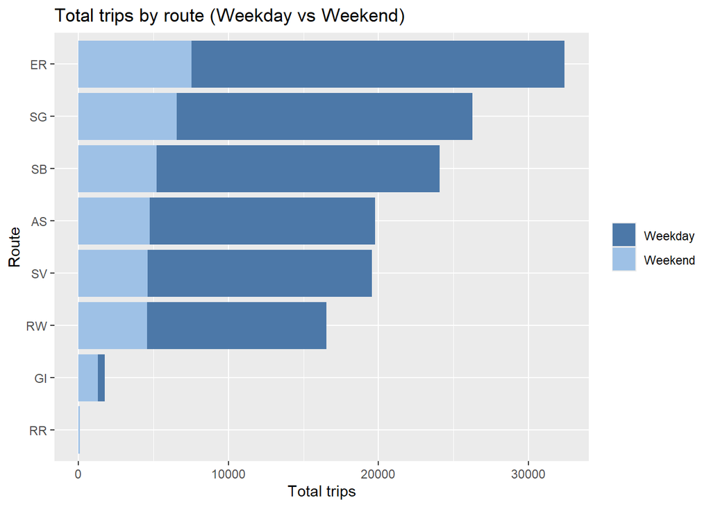

```r
ggplot(route_weekpart, aes(x = reorder(route_no, total_trips, FUN = sum), y = total_trips, fill = day_type)) +
  geom_col(position = "stack") +
  coord_flip() +
  labs(x = "Route", y = "Total trips", fill = NULL, title = "Total trips by route (Weekday vs Weekend)") +
  scale_fill_manual(values = c("Weekday" = "#4C78A8", "Weekend" = "#9EC1E6"))
```

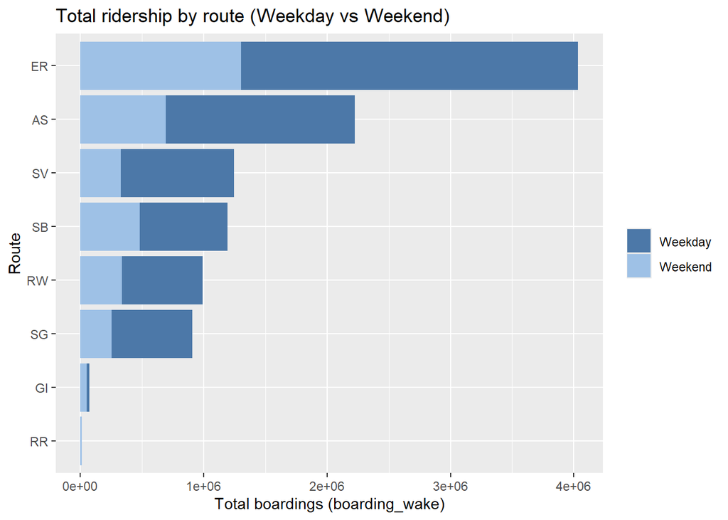

```r
ggplot(route_weekpart, aes(x = reorder(route_no, total_boardings, FUN = sum), y = total_boardings, fill = day_type)) +
  geom_col(position = "stack") +
  coord_flip() +
  labs(x = "Route", y = "Total boardings (boarding_wake)", fill = NULL,
       title = "Total ridership by route (Weekday vs Weekend)") +
  scale_fill_manual(values = c("Weekday" = "#4C78A8", "Weekend" = "#9EC1E6"))
```

```r
route_avg_weekpart <- trip_tbl %>%
  mutate(day_type = if_else(is_weekday, "Weekday", "Weekend")) %>%
  group_by(route_no, day_type) %>%
  summarise(
    avg_boardings_per_trip = mean(trip_boardings, na.rm = TRUE),
    n_trips = n(),
    .groups = "drop"
  )

route_avg_weekpart
```

```
## # A tibble: 16 × 4
##    route_no day_type avg_boardings_per_trip n_trips
##    <chr>    <chr>                     <dbl>   <int>
##  1 AS       Weekday                   102.    15047
##  2 AS       Weekend                   146.     4732
##  3 ER       Weekday                   110.    24863
##  4 ER       Weekend                   173.     7541
##  5 GI       Weekday                    51.7     444
##  6 GI       Weekend                    38.6    1292
##  7 RR       Weekday                   150         6
##  8 RR       Weekend                   107.       84
##  9 RW       Weekday                    54.8   11950
## 10 RW       Weekend                    72.9    4582
## 11 SB       Weekday                    37.6   18900
## 12 SB       Weekend                    92.9    5189
## 13 SG       Weekday                    33.1   19744
## 14 SG       Weekend                    38.8    6534
## 15 SV       Weekday                    61.5   14933
## 16 SV       Weekend                    70.8    4617
```

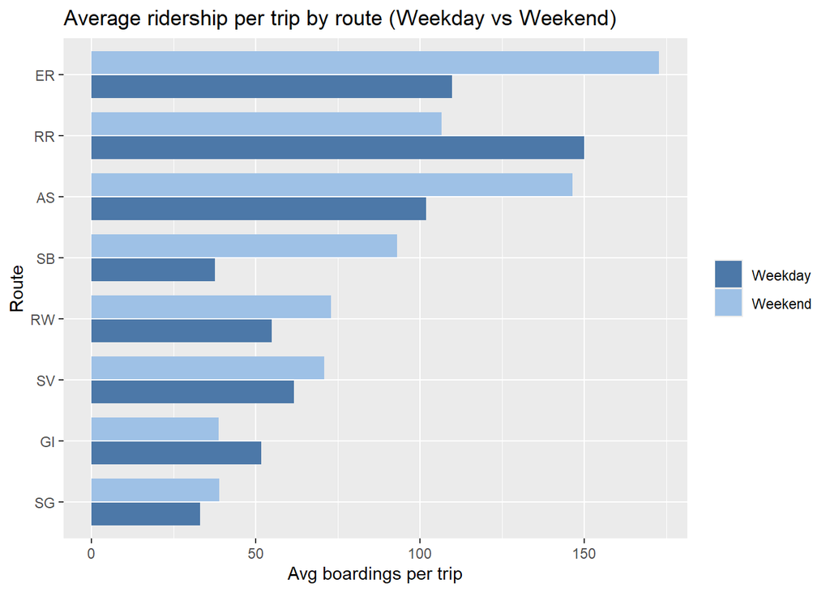

```r
ggplot(route_avg_weekpart,
       aes(x = reorder(route_no, avg_boardings_per_trip, FUN = max),
           y = avg_boardings_per_trip, fill = day_type)) +
  geom_col(position = position_dodge(width = 0.8), width = 0.75) +
  coord_flip() +
  labs(x = "Route", y = "Avg boardings per trip", fill = NULL,
       title = "Average ridership per trip by route (Weekday vs Weekend)") +
  scale_fill_manual(values = c("Weekday" = "#4C78A8", "Weekend" = "#9EC1E6"))
```

### Stop totals: cumulative boardings/alightings

```r
stop_totals <- dat %>%
  group_by(stop_id, stop_name) %>%
  summarise(
    total_boardings = sum(boarding_wake, na.rm = TRUE),
    total_alightings = sum(alightings_wake, na.rm = TRUE),
    .groups = "drop"
  ) %>%
  arrange(desc(total_boardings))

stop_totals
```

```
## # A tibble: 25 × 4
##    stop_id stop_name           total_boardings total_alightings
##      <dbl> <chr>                         <dbl>            <dbl>
##  1      87 Wall St/Pier 11             2163606          2562903
##  2      17 East 34th Street            1404634          1566502
##  3      20 Dumbo/Fulton Ferry           990641           884891
##  4      19 North Williamsburg           560850           520351
##  5     113 East 90th St                 533628           489918
##  6      88 Rockaway                     438062           435374
##  7      18 Greenpoint                   431993           388197
##  8       4 Hunters Point South          417259           397537
##  9      89 Astoria                      414117           342461
## 10     137 St. George                   387301           331679
## # ℹ 15 more rows
```

### Monthly (2024-01 to 2025-06): trips, ridership, avg per trip (weekday vs weekend stacked)

```r
monthly_weekpart <- trip_tbl %>%
  filter(month >= ymd("2024-01-01"), month <= ymd("2025-06-01")) %>%
  mutate(day_type = if_else(is_weekday, "Weekday", "Weekend")) %>%
  group_by(month, day_type) %>%
  summarise(
    total_trips = n(),
    total_boardings = sum(trip_boardings, na.rm = TRUE),
    .groups = "drop"
  ) %>%
  arrange(month, day_type)

monthly_weekpart
```

```
## # A tibble: 36 × 4
##    month      day_type total_trips total_boardings
##    <date>     <chr>          <int>           <dbl>
##  1 2024-01-01 Weekday         5912          254505
##  2 2024-01-01 Weekend         1176           49751
##  3 2024-02-01 Weekday         5547          250456
##  4 2024-02-01 Weekend         1176           76538
##  5 2024-03-01 Weekday         5671          307774
##  6 2024-03-01 Weekend         1610          142854
##  7 2024-04-01 Weekday         6041          393761
##  8 2024-04-01 Weekend         1799          179812
##  9 2024-05-01 Weekday         6290          485912
## 10 2024-05-01 Weekend         1982          233380
## # ℹ 26 more rows
```

```r
monthly_avg <- trip_tbl %>%
  filter(month >= ymd("2024-01-01"), month <= ymd("2025-06-01")) %>%
  group_by(month) %>%
  summarise(
    total_trips = n(),
    total_boardings = sum(trip_boardings, na.rm = TRUE),
    avg_boardings_per_trip = total_boardings / total_trips,
    .groups = "drop"
  ) %>%
  arrange(month)

monthly_avg
```

```
## # A tibble: 18 × 4
##    month      total_trips total_boardings avg_boardings_per_trip
##    <date>           <int>           <dbl>                  <dbl>
##  1 2024-01-01        7088          304256                   42.9
##  2 2024-02-01        6723          326994                   48.6
##  3 2024-03-01        7281          450628                   61.9
##  4 2024-04-01        7840          573573                   73.2
##  5 2024-05-01        8272          719292                   87.0
##  6 2024-06-01        8733          903588                  103.
##  7 2024-07-01        8981          930615                  104.
##  8 2024-08-01        8932          869152                   97.3
##  9 2024-09-01        8157          736717                   90.3
## 10 2024-10-01        8352          770999                   92.3
## 11 2024-11-01        6929          483251                   69.7
## 12 2024-12-01        7051          372253                   52.8
## 13 2025-01-01        7165          321049                   44.8
## 14 2025-02-01        6527          310019                   47.5
## 15 2025-03-01        7233          471718                   65.2
## 16 2025-04-01        8046          633943                   78.8
## 17 2025-05-01        8371          728241                   87.0
## 18 2025-06-01        8777          770018                   87.7
```

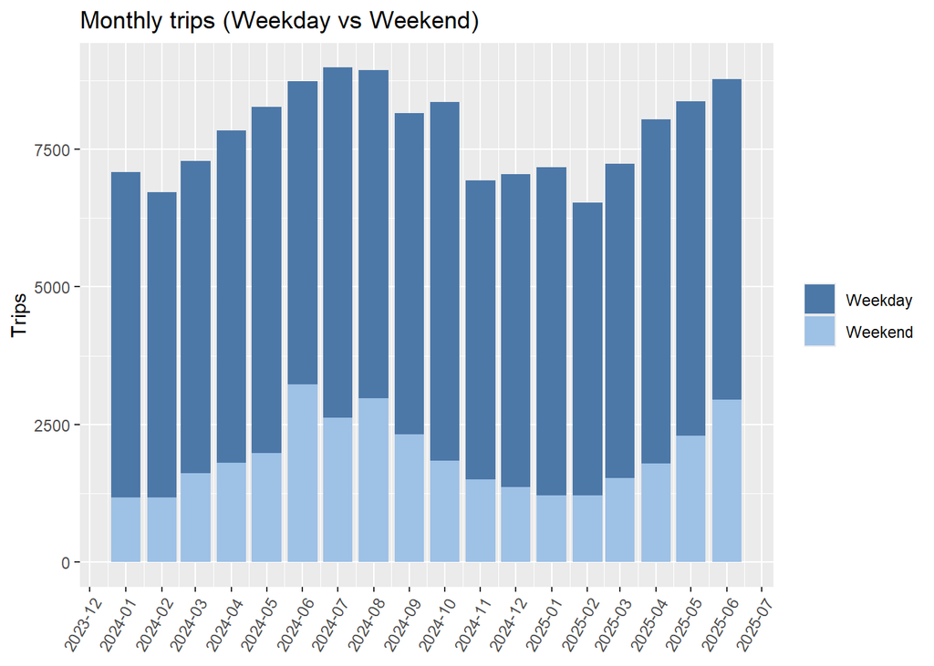

```r
ggplot(monthly_weekpart, aes(x = month, y = total_trips, fill = day_type)) +
  geom_col(position = "stack") +
  scale_x_date(date_breaks = "1 month", date_labels = "%Y-%m") +
  labs(x = NULL, y = "Trips", fill = NULL, title = "Monthly trips (Weekday vs Weekend)") +
  theme(axis.text.x = element_text(angle = 60, hjust = 1)) +
  scale_fill_manual(values = c("Weekday" = "#4C78A8", "Weekend" = "#9EC1E6"))
```

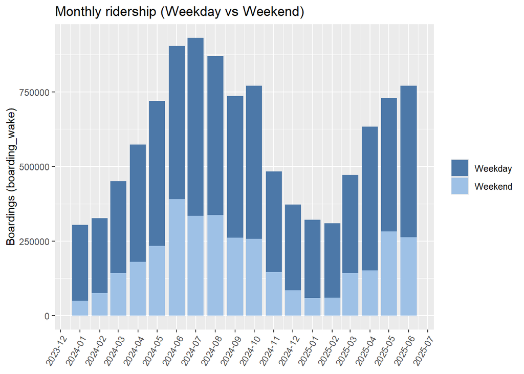

```r
ggplot(monthly_weekpart, aes(x = month, y = total_boardings, fill = day_type)) +
  geom_col(position = "stack") +
  scale_x_date(date_breaks = "1 month", date_labels = "%Y-%m") +
  labs(x = NULL, y = "Boardings (boarding_wake)", fill = NULL, title = "Monthly ridership (Weekday vs Weekend)") +
  theme(axis.text.x = element_text(angle = 60, hjust = 1)) +
  scale_fill_manual(values = c("Weekday" = "#4C78A8", "Weekend" = "#9EC1E6"))
```

```r
monthly_avg_weekpart <- trip_tbl %>%
  filter(month >= ymd("2024-01-01"), month <= ymd("2025-06-01")) %>%
  mutate(day_type = if_else(is_weekday, "Weekday", "Weekend")) %>%
  group_by(month, day_type) %>%
  summarise(
    avg_boardings_per_trip = mean(trip_boardings, na.rm = TRUE),
    n_trips = n(),
    .groups = "drop"
  )

monthly_avg_weekpart
```

```
## # A tibble: 36 × 4
##    month      day_type avg_boardings_per_trip n_trips
##    <date>     <chr>                     <dbl>   <int>
##  1 2024-01-01 Weekday                    43.0    5912
##  2 2024-01-01 Weekend                    42.3    1176
##  3 2024-02-01 Weekday                    45.2    5547
##  4 2024-02-01 Weekend                    65.1    1176
##  5 2024-03-01 Weekday                    54.3    5671
##  6 2024-03-01 Weekend                    88.7    1610
##  7 2024-04-01 Weekday                    65.2    6041
##  8 2024-04-01 Weekend                   100.0    1799
##  9 2024-05-01 Weekday                    77.3    6290
## 10 2024-05-01 Weekend                   118.     1982
## # ℹ 26 more rows
```

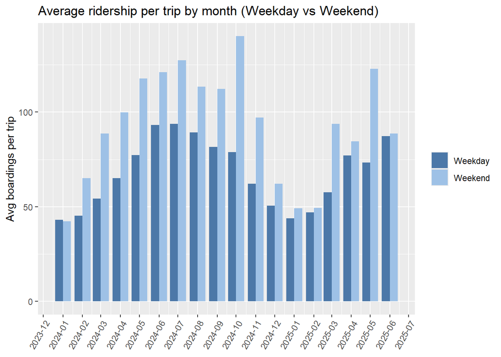

```r
ggplot(monthly_avg_weekpart, aes(x = month, y = avg_boardings_per_trip, fill = day_type)) +
  geom_col(position = position_dodge(width = 25), width = 25) +
  scale_x_date(date_breaks = "1 month", date_labels = "%Y-%m") +
  labs(x = NULL, y = "Avg boardings per trip", fill = NULL,
       title = "Average ridership per trip by month (Weekday vs Weekend)") +
  theme(axis.text.x = element_text(angle = 60, hjust = 1)) +
  scale_fill_manual(values = c("Weekday" = "#4C78A8", "Weekend" = "#9EC1E6"))
```

### By departure hour (0–23), stop-level (weekday vs weekend)

Instead of assigning one hour per trip, we compare patterns at the stop level using each stop’s actual_departure_dt. We summarize (1) number of stop departures, (2) total boardings, and (3) average boardings per stop.

```r
stop_hour_weekpart <- dat %>%
  filter(!is.na(actual_departure_dt)) %>%
  mutate(
    dep_hour = hour(actual_departure_dt),
    day_type = if_else(is_weekday, "Weekday", "Weekend")
  ) %>%
  filter(dep_hour >= 0, dep_hour <= 23, dep_hour != 23) %>%
  group_by(dep_hour, day_type) %>%
  summarise(
    n_stop_departures = n(),
    total_boardings = sum(boarding_wake, na.rm = TRUE),
    avg_boardings_per_stop = total_boardings / n_stop_departures,
    .groups = "drop"
  ) %>%
  arrange(dep_hour, day_type)

stop_hour_weekpart
```

```
## # A tibble: 34 × 5
##    dep_hour day_type n_stop_departures total_boardings avg_boardings_per_stop
##       <int> <chr>                <int>           <dbl>                  <dbl>
##  1        5 Weekday               3952           36452                   9.22
##  2        6 Weekday              20977          150596                   7.18
##  3        7 Weekday              34876          481715                  13.8
##  4        7 Weekend                226            2073                   9.17
##  5        8 Weekday              35082          662104                  18.9
##  6        8 Weekend               2531           18147                   7.17
##  7        9 Weekday              36191          405701                  11.2
##  8        9 Weekend               8745          107551                  12.3
##  9       10 Weekday              29766          310148                  10.4
## 10       10 Weekend               9459          161616                  17.1
## # ℹ 24 more rows
```

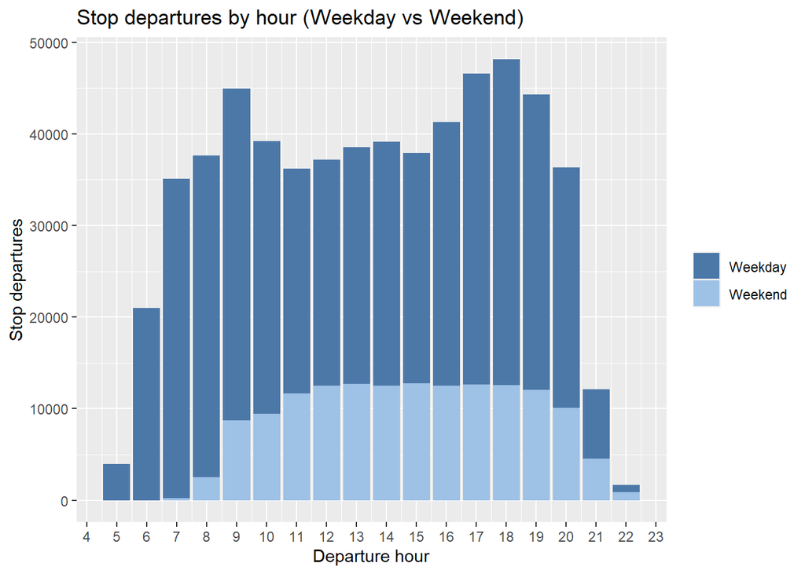

```r
ggplot(stop_hour_weekpart, aes(x = dep_hour, y = n_stop_departures, fill = day_type)) +
  geom_col(position = "stack") +
  scale_x_continuous(breaks = 0:23) +
  labs(x = "Departure hour", y = "Stop departures", fill = NULL,
       title = "Stop departures by hour (Weekday vs Weekend)") +
  scale_fill_manual(values = c("Weekday" = "#4C78A8", "Weekend" = "#9EC1E6"))
```

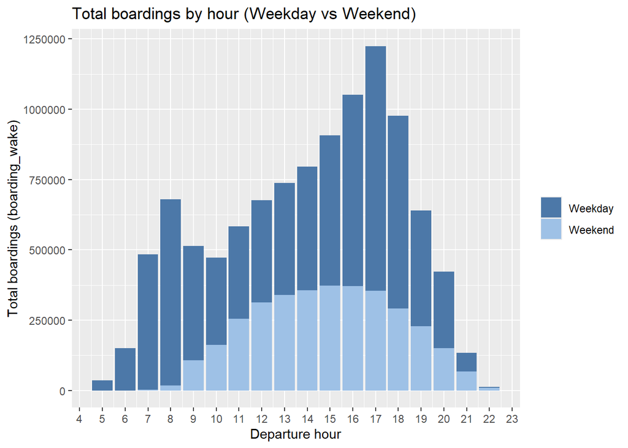

```r
ggplot(stop_hour_weekpart, aes(x = dep_hour, y = total_boardings, fill = day_type)) +
  geom_col(position = "stack") +
  scale_x_continuous(breaks = 0:23) +
  labs(x = "Departure hour", y = "Total boardings (boarding_wake)", fill = NULL,
       title = "Total boardings by hour (Weekday vs Weekend)") +
  scale_fill_manual(values = c("Weekday" = "#4C78A8", "Weekend" = "#9EC1E6"))
```

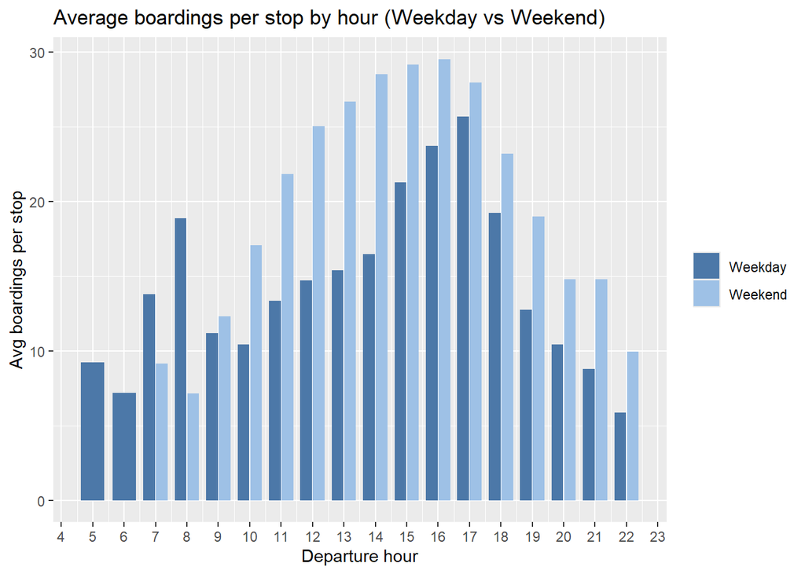

```r
ggplot(stop_hour_weekpart, aes(x = dep_hour, y = avg_boardings_per_stop, fill = day_type)) +
  geom_col(position = position_dodge(width = 0.8), width = 0.75) +
  scale_x_continuous(breaks = 0:23) +
  labs(x = "Departure hour", y = "Avg boardings per stop", fill = NULL,
       title = "Average boardings per stop by hour (Weekday vs Weekend)") +
  scale_fill_manual(values = c("Weekday" = "#4C78A8", "Weekend" = "#9EC1E6"))
```

### Distributions: boardings/alightings/lbr/onboard/load_factor

We handle NAs with na.rm = TRUE. For onboard and load_factor, negative values are set to 0 for distribution purposes.

```r
dist_dat <- dat %>%
  mutate(
    onboard_nonneg = pmax(onboard, 0),
    load_factor_nonneg = onboard_nonneg / Vessel_Capacity,
    stop_volume = boarding_wake + alightings_wake
  )
```

```r
make_bin_table <- function(x, breaks, labels = NULL) {
  tibble(x = x) %>%
    filter(!is.na(x)) %>%
    mutate(bin = cut(x, breaks = breaks, include.lowest = TRUE, right = TRUE, labels = labels)) %>%
    count(bin, name = "n") %>%
    mutate(pct = n / sum(n)) %>%
    arrange(bin)
}

board_bins <- make_bin_table(dist_dat$boarding_wake, breaks = c(-Inf, 0, 1, 5, 10, 20, 50, 100, Inf))
alight_bins <- make_bin_table(dist_dat$alightings_wake, breaks = c(-Inf, 0, 1, 5, 10, 20, 50, 100, Inf))

board_bins
```

```
## # A tibble: 8 × 3
##   bin             n    pct
##   <fct>       <int>  <dbl>
## 1 [-Inf,0]   202266 0.268
## 2 (0,1]       33630 0.0446
## 3 (1,5]      121013 0.161
## 4 (5,10]     105465 0.140
## 5 (10,20]    124051 0.165
## 6 (20,50]    119843 0.159
## 7 (50,100]    39802 0.0528
## 8 (100, Inf]   7642 0.0101
```

```r
alight_bins
```

```
## # A tibble: 8 × 3
##   bin             n    pct
##   <fct>       <int>  <dbl>
## 1 [-Inf,0]   205490 0.273
## 2 (0,1]       39066 0.0518
## 3 (1,5]      125933 0.167
## 4 (5,10]      98805 0.131
## 5 (10,20]    112565 0.149
## 6 (20,50]    124574 0.165
## 7 (50,100]    38851 0.0515
## 8 (100, Inf]   8426 0.0112
```

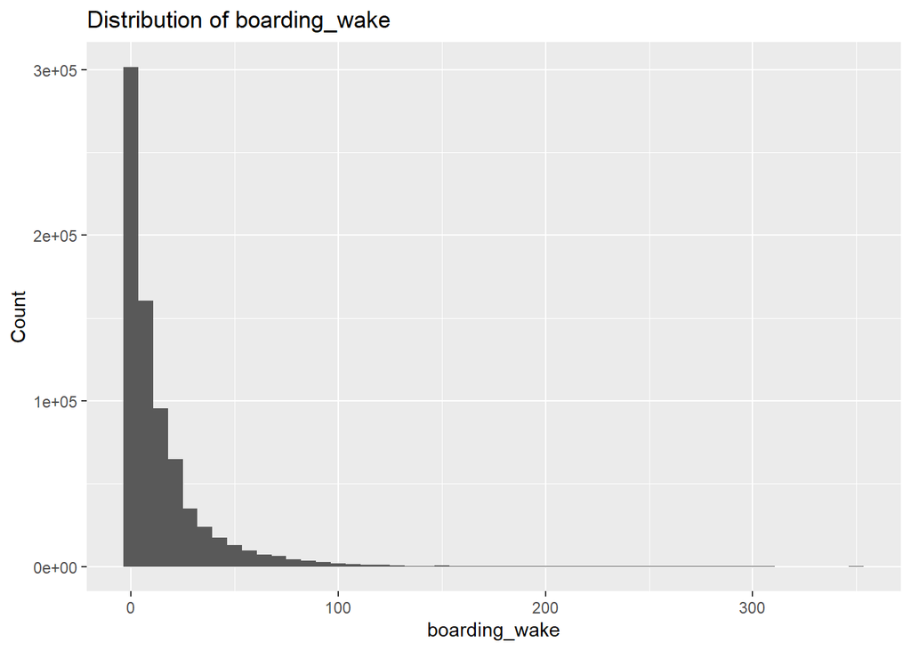

```r
ggplot(dist_dat %>% filter(!is.na(boarding_wake)), aes(x = boarding_wake)) +
  geom_histogram(bins = 50) +
  labs(title = "Distribution of boarding_wake", x = "boarding_wake", y = "Count")
```

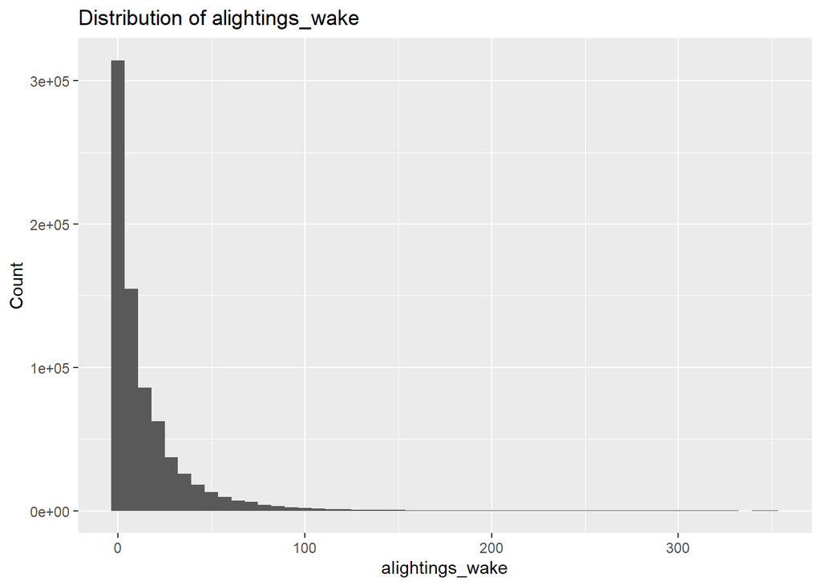

```r
ggplot(dist_dat %>% filter(!is.na(alightings_wake)), aes(x = alightings_wake)) +
  geom_histogram(bins = 50) +
  labs(title = "Distribution of alightings_wake", x = "alightings_wake", y = "Count")
```

```r
lbr_table <- dist_dat %>%
  filter(!is.na(lbr)) %>%
  count(lbr, name = "n") %>%
  mutate(pct = n / sum(n)) %>%
  arrange(desc(lbr))

lbr_table
```

```
## # A tibble: 132 × 3
##      lbr     n        pct
##    <dbl> <int>      <dbl>
##  1   400     1 0.00000133
##  2   380     1 0.00000133
##  3   360     1 0.00000133
##  4   300     7 0.00000929
##  5   275     1 0.00000133
##  6   263     1 0.00000133
##  7   255     1 0.00000133
##  8   250     5 0.00000663
##  9   220     2 0.00000265
## 10   205     1 0.00000133
## # ℹ 122 more rows
```

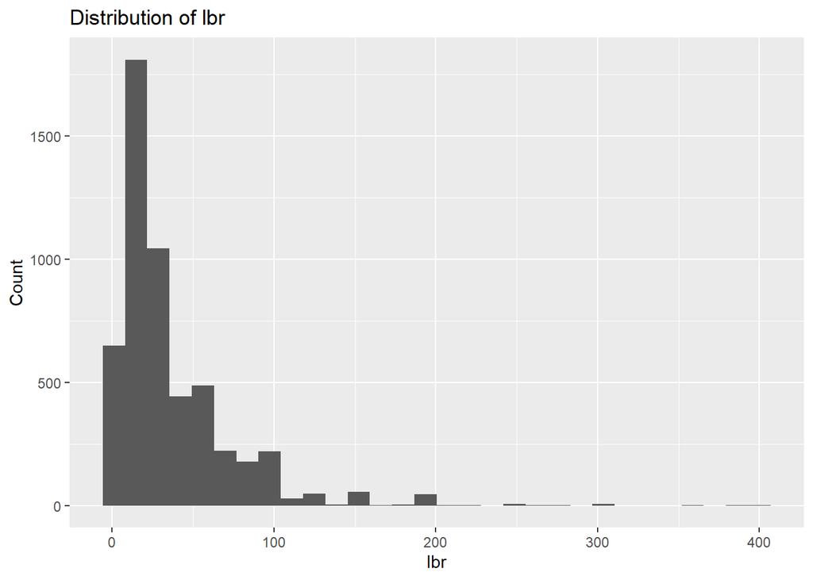

```r
ggplot(dist_dat %>% filter(!is.na(lbr) & lbr > 0), aes(x = lbr)) +
  geom_histogram(bins = 30) +
  labs(title = "Distribution of lbr", x = "lbr", y = "Count")
```

```r
onboard_bins <- make_bin_table(dist_dat$onboard_nonneg, breaks = c(-Inf, 0, 25, 50, 75, 100, 150, 250, 350, Inf))
load_bins <- make_bin_table(dist_dat$load_factor_nonneg, breaks = c(-Inf, 0, 0.25, 0.5, 0.75, 1.0, Inf))

onboard_bins
```

```
## # A tibble: 8 × 3
##   bin            n     pct
##   <fct>      <int>   <dbl>
## 1 [-Inf,0]  155014 0.206
## 2 (0,25]    281961 0.374
## 3 (25,50]   149714 0.199
## 4 (50,75]    76115 0.101
## 5 (75,100]   40613 0.0539
## 6 (100,150]  42840 0.0568
## 7 (150,250]   6409 0.00850
## 8 (250,350]   1059 0.00141
```

```r
load_bins
```

```
## # A tibble: 6 × 3
##   bin             n      pct
##   <fct>       <int>    <dbl>
## 1 [-Inf,0]   149946 0.204
## 2 (0,0.25]   418729 0.571
## 3 (0.25,0.5] 111780 0.152
## 4 (0.5,0.75]  32968 0.0449
## 5 (0.75,1]    20021 0.0273
## 6 (1, Inf]      139 0.000189
```

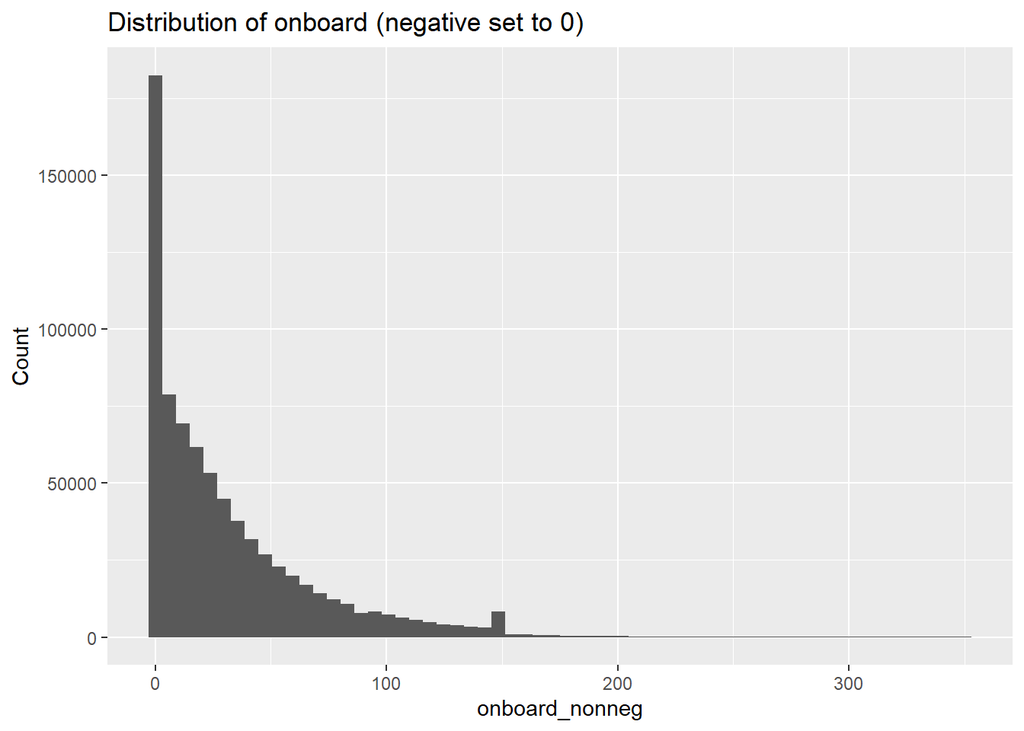

```r
ggplot(dist_dat %>% filter(!is.na(onboard_nonneg)), aes(x = onboard_nonneg)) +
  geom_histogram(bins = 60) +
  labs(title = "Distribution of onboard (negative set to 0)", x = "onboard_nonneg", y = "Count")
```

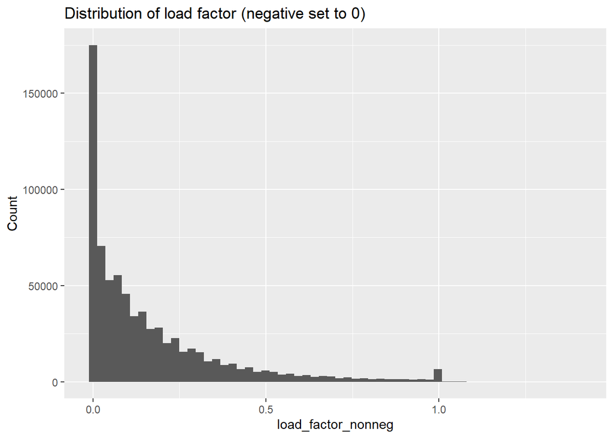

```r
ggplot(dist_dat %>% filter(!is.na(load_factor_nonneg)), aes(x = load_factor_nonneg)) +
  geom_histogram(bins = 60) +
  labs(title = "Distribution of load factor (negative set to 0)", x = "load_factor_nonneg", y = "Count")
```

### Delay/status tables + distributions of key time metrics

```r
arr_status_tab <- dist_dat %>%
  filter(!is.na(arr_status)) %>%
  count(arr_status, name = "n") %>%
  mutate(pct = n / sum(n)) %>%
  arrange(desc(n))

dep_status_tab <- dist_dat %>%
  filter(!is.na(dep_status)) %>%
  count(dep_status, name = "n") %>%
  mutate(pct = n / sum(n)) %>%
  arrange(desc(n))

arr_status_tab
```

```
## # A tibble: 2 × 3
##   arr_status      n    pct
##   <chr>       <int>  <dbl>
## 1 Not_Late   558461 0.931
## 2 Late        41247 0.0688
```

```r
dep_status_tab
```

```
## # A tibble: 2 × 3
##   dep_status      n     pct
##   <chr>       <int>   <dbl>
## 1 Not_Early  599953 0.998
## 2 Early        1155 0.00192
```

```r
arrdiff_bins <- make_bin_table(dist_dat$arr_diff, breaks = seq(-20, 75, by = 5))
depdiff_bins <- make_bin_table(dist_dat$dep_diff, breaks = seq(-20, 75, by = 5))
waterdiff_bins <- make_bin_table(dist_dat$water_diff, breaks = seq(-60, 60, by = 5))
dwell_bins <- make_bin_table(dist_dat$act_dwell_min, breaks = seq(0, 60, by = 2))

arrdiff_bins
```

```
## # A tibble: 18 × 3
##    bin            n        pct
##    <fct>      <int>      <dbl>
##  1 [-20,-15]      4 0.00000667
##  2 (-15,-10]     30 0.0000500
##  3 (-10,-5]   14966 0.0250
##  4 (-5,0]    376889 0.628
##  5 (0,5]     166572 0.278
##  6 (5,10]     28108 0.0469
##  7 (10,15]     7374 0.0123
##  8 (15,20]     2933 0.00489
##  9 (20,25]     1374 0.00229
## 10 (25,30]      730 0.00122
## 11 (30,35]      364 0.000607
## 12 (35,40]      193 0.000322
## 13 (40,45]      117 0.000195
## 14 (45,50]       33 0.0000550
## 15 (50,55]       15 0.0000250
## 16 (55,60]        3 0.00000500
## 17 (60,65]        1 0.00000167
## 18 (70,75]        2 0.00000333
```

```r
depdiff_bins
```

```
## # A tibble: 19 × 3
##    bin            n        pct
##    <fct>      <int>      <dbl>
##  1 [-20,-15]      2 0.00000333
##  2 (-15,-10]      4 0.00000665
##  3 (-10,-5]     136 0.000226
##  4 (-5,0]     17367 0.0289
##  5 (0,5]     493601 0.821
##  6 (5,10]     66700 0.111
##  7 (10,15]    13806 0.0230
##  8 (15,20]     5070 0.00843
##  9 (20,25]     2222 0.00370
## 10 (25,30]     1131 0.00188
## 11 (30,35]      483 0.000804
## 12 (35,40]      278 0.000462
## 13 (40,45]      166 0.000276
## 14 (45,50]       90 0.000150
## 15 (50,55]       28 0.0000466
## 16 (55,60]       13 0.0000216
## 17 (60,65]        6 0.00000998
## 18 (70,75]        3 0.00000499
## 19 <NA>           2 0.00000333
```

```r
waterdiff_bins
```

```
## # A tibble: 16 × 3
##    bin            n        pct
##    <fct>      <int>      <dbl>
##  1 (-20,-15]      8 0.0000134
##  2 (-15,-10]    229 0.000383
##  3 (-10,-5]  153352 0.257
##  4 (-5,0]    412492 0.690
##  5 (0,5]      30230 0.0506
##  6 (5,10]      1207 0.00202
##  7 (10,15]      172 0.000288
##  8 (15,20]       46 0.0000769
##  9 (20,25]       37 0.0000619
## 10 (25,30]        8 0.0000134
## 11 (30,35]        4 0.00000669
## 12 (35,40]        1 0.00000167
## 13 (40,45]        3 0.00000502
## 14 (45,50]        5 0.00000836
## 15 (50,55]        1 0.00000167
## 16 <NA>           1 0.00000167
```

```r
dwell_bins
```

```
## # A tibble: 26 × 3
##    bin          n       pct
##    <fct>    <int>     <dbl>
##  1 [0,2]    29189 0.0632
##  2 (2,4]   261781 0.567
##  3 (4,6]   141200 0.306
##  4 (6,8]    24628 0.0534
##  5 (8,10]    3990 0.00864
##  6 (10,12]    571 0.00124
##  7 (12,14]     87 0.000188
##  8 (14,16]     32 0.0000693
##  9 (16,18]     27 0.0000585
## 10 (18,20]     25 0.0000542
## # ℹ 16 more rows
```

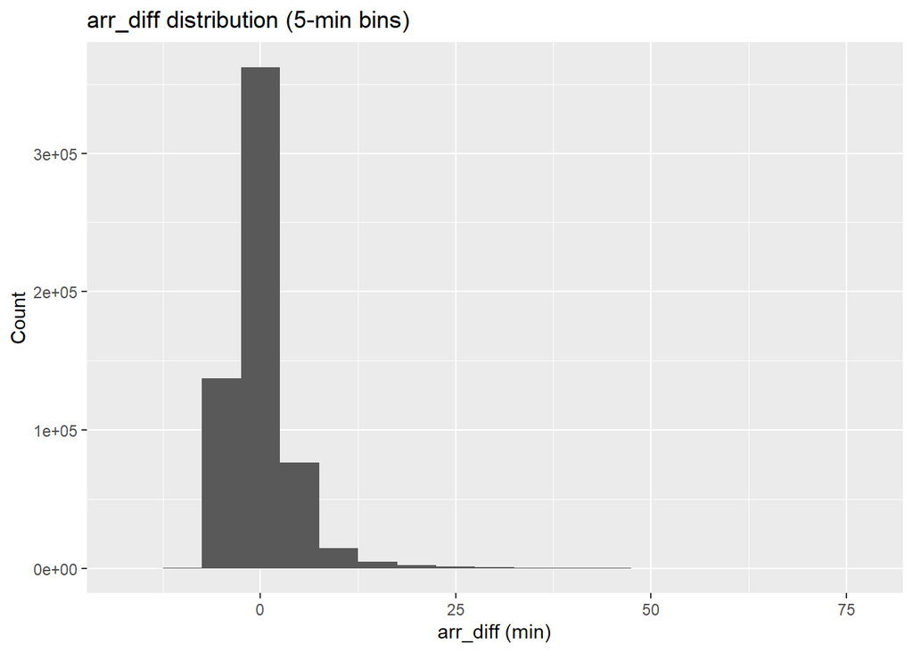

```r
ggplot(dist_dat %>% filter(!is.na(arr_diff)), aes(x = arr_diff)) +
  geom_histogram(binwidth = 5) +
  labs(title = "arr_diff distribution (5-min bins)", x = "arr_diff (min)", y = "Count")
```

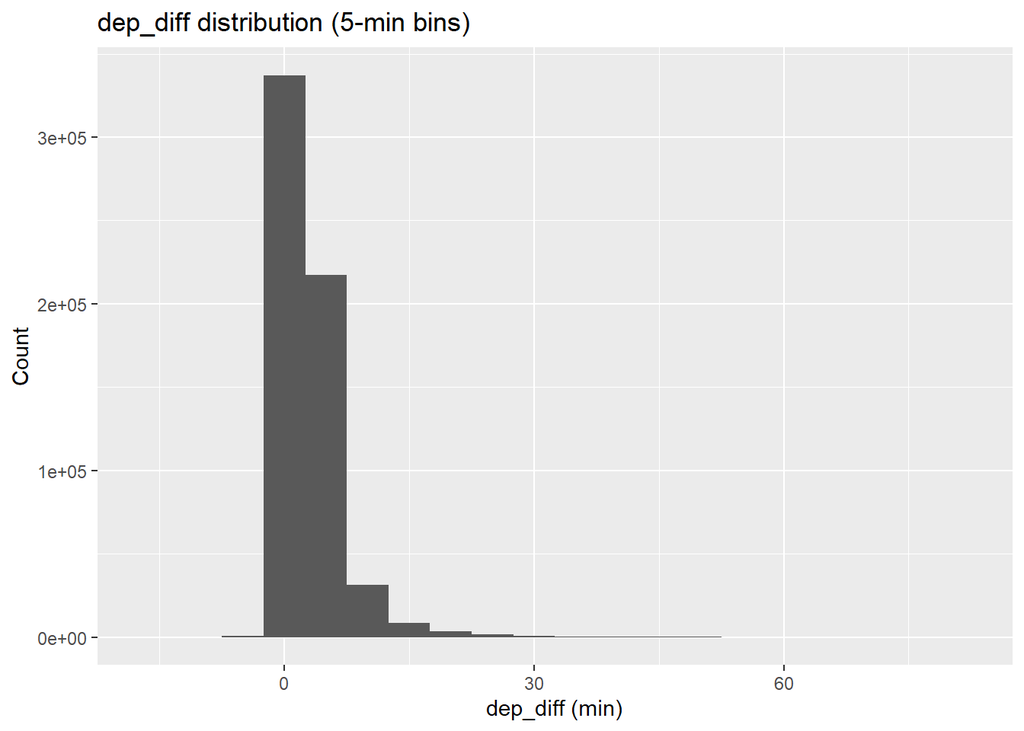

```r
ggplot(dist_dat %>% filter(!is.na(dep_diff)), aes(x = dep_diff)) +
  geom_histogram(binwidth = 5) +
  labs(title = "dep_diff distribution (5-min bins)", x = "dep_diff (min)", y = "Count")
```

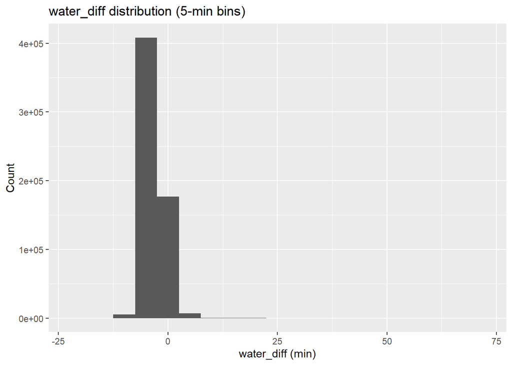

```r
ggplot(dist_dat %>% filter(!is.na(water_diff)), aes(x = water_diff)) +
  geom_histogram(binwidth = 5) +
  labs(title = "water_diff distribution (5-min bins)", x = "water_diff (min)", y = "Count")
```

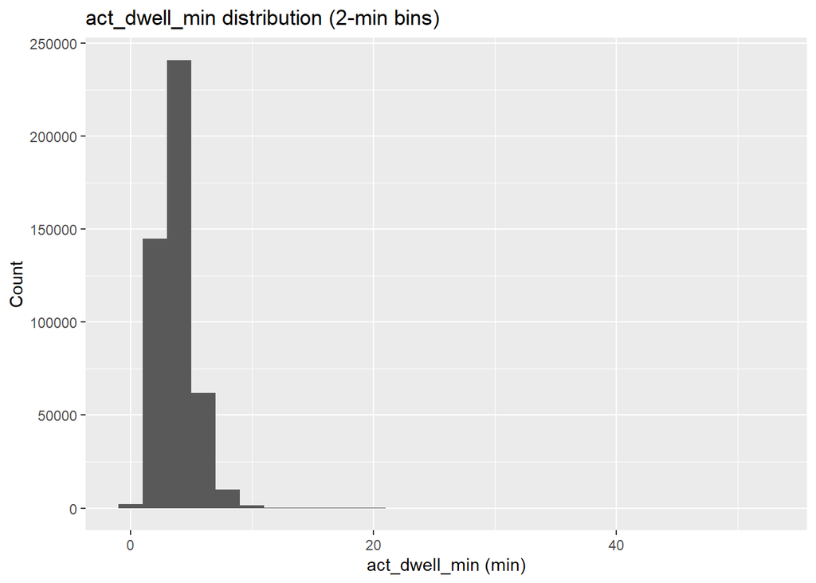

```r
ggplot(dist_dat %>% filter(!is.na(act_dwell_min)), aes(x = act_dwell_min)) +
  geom_histogram(binwidth = 2) +
  labs(title = "act_dwell_min distribution (2-min bins)", x = "act_dwell_min (min)", y = "Count")
```

### arr_diff patterns + correlation with passenger activity

We examine arr_diff variation by route, month, weekday/weekend, and time-of-day. We also check its relationship with passenger activity (boarding_wake + alightings_wake).

```r
arr_by_route <- dist_dat %>%
  filter(!is.na(arr_diff)) %>%
  group_by(route_no) %>%
  summarise(
    n = n(),
    mean = mean(arr_diff),
    p50 = quantile(arr_diff, 0.50),
    p90 = quantile(arr_diff, 0.90),
    .groups = "drop"
  ) %>%
  arrange(desc(mean))

arr_by_route
```

```
## # A tibble: 8 × 5
##   route_no      n   mean   p50   p90
##   <chr>     <int>  <dbl> <dbl> <dbl>
## 1 RW        31870  2.44      1  8
## 2 GI         1622  0.663     0  4.1
## 3 SV        95635  0.563     0  5
## 4 AS       116669 -0.170    -1  3.05
## 5 SB       111098 -0.195    -1  4
## 6 SG        51553 -0.260    -1  3.15
## 7 ER       191089 -0.456    -1  3.58
## 8 RR          172 -1.48     -2  5
```

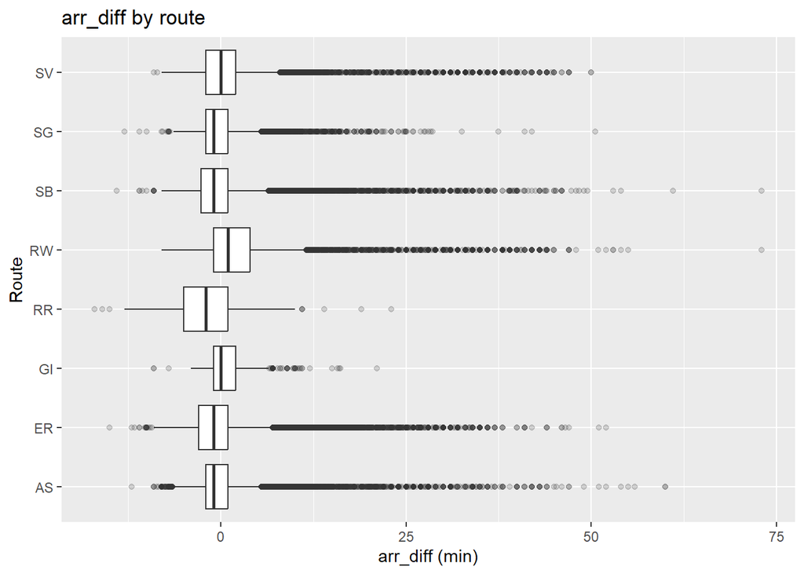

```r
ggplot(dist_dat %>% filter(!is.na(arr_diff)), aes(x = route_no, y = arr_diff)) +
  geom_boxplot(outlier.alpha = 0.2) +
  coord_flip() +
  labs(title = "arr_diff by route", x = "Route", y = "arr_diff (min)")
```

```r
arr_by_month <- dist_dat %>%
  filter(!is.na(arr_diff)) %>%
  mutate(month = floor_date(trip_date, "month")) %>%
  group_by(month, is_weekday) %>%
  summarise(
    n = n(),
    mean = mean(arr_diff),
    p50 = quantile(arr_diff, 0.50),
    p90 = quantile(arr_diff, 0.90),
    .groups = "drop"
  ) %>%
  arrange(month, is_weekday)

arr_by_month
```

```
## # A tibble: 36 × 6
##    month      is_weekday     n     mean   p50   p90
##    <date>     <lgl>      <int>    <dbl> <dbl> <dbl>
##  1 2024-01-01 FALSE       4960 -0.0216     -1     4
##  2 2024-01-01 TRUE       24647 -0.514      -1     3
##  3 2024-02-01 FALSE       5052  0.548      -1     5
##  4 2024-02-01 TRUE       23016 -0.492      -1     3
##  5 2024-03-01 FALSE       7033  1.64        0     9
##  6 2024-03-01 TRUE       23804 -0.356      -1     3
##  7 2024-04-01 FALSE       8033  0.00498    -1     5
##  8 2024-04-01 TRUE       25597 -0.259      -1     4
##  9 2024-05-01 FALSE       8548  0.0101     -1     5
## 10 2024-05-01 TRUE       25981 -0.0632     -1     4
## # ℹ 26 more rows
```

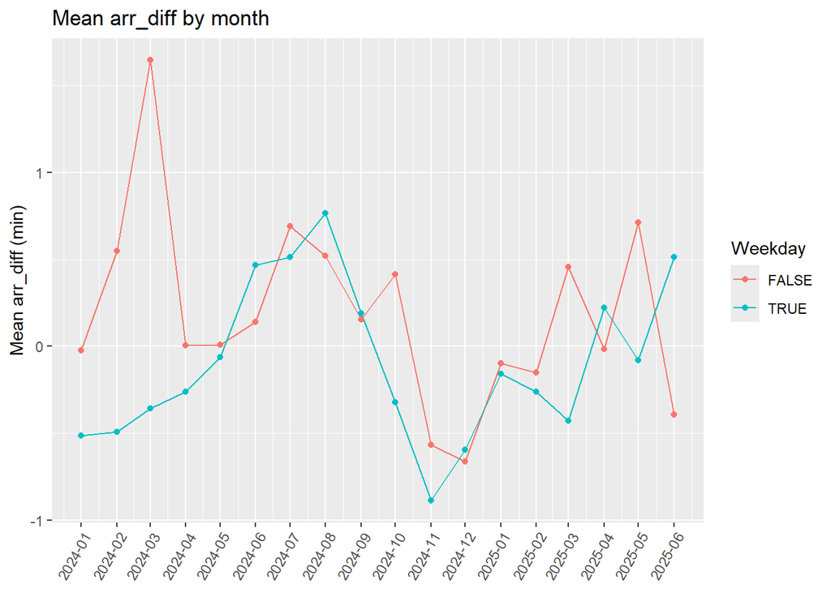

```r
ggplot(arr_by_month, aes(x = month, y = mean, color = is_weekday)) +
  geom_line() +
  geom_point() +
  scale_x_date(date_breaks = "1 month", date_labels = "%Y-%m") +
  labs(title = "Mean arr_diff by month", x = NULL, y = "Mean arr_diff (min)", color = "Weekday") +
  theme(axis.text.x = element_text(angle = 60, hjust = 1))
```

```r
arr_by_daytype <- dist_dat %>%
  filter(!is.na(arr_diff)) %>%
  mutate(day_type = if_else(is_weekday, "Weekday", "Weekend")) %>%
  group_by(day_type) %>%
  summarise(
    n = n(),
    mean = mean(arr_diff),
    p25 = quantile(arr_diff, 0.25),
    p50 = quantile(arr_diff, 0.50),
    p75 = quantile(arr_diff, 0.75),
    .groups = "drop"
  )

arr_by_daytype
```

```
## # A tibble: 2 × 6
##   day_type      n    mean   p25   p50   p75
##   <chr>     <int>   <dbl> <dbl> <dbl> <dbl>
## 1 Weekday  451409 -0.0900 -2       -1   1
## 2 Weekend  148299  0.210  -2.91    -1   1.9
```

```r
arr_by_hour <- dist_dat %>%
  filter(!is.na(arr_diff), !is.na(actual_departure_dt), hour(actual_departure_dt) != 23) %>%
  mutate(dep_hour = hour(actual_departure_dt),
         day_type = if_else(is_weekday, "Weekday", "Weekend")) %>%
  group_by(dep_hour, day_type) %>%
  summarise(
    n = n(),
    mean = mean(arr_diff),
    p50 = quantile(arr_diff, 0.50),
    .groups = "drop"
  ) %>%
  arrange(dep_hour, day_type)

arr_by_hour
```

```
## # A tibble: 33 × 5
##    dep_hour day_type     n   mean   p50
##       <int> <chr>    <int>  <dbl> <dbl>
##  1        5 Weekday   2549 -1.22  -1.08
##  2        6 Weekday  14258 -0.976 -1
##  3        7 Weekday  25754 -1.30  -1.97
##  4        8 Weekday  26789 -0.724 -1
##  5        8 Weekend   1582 -2.17  -2.55
##  6        9 Weekday  27503 -0.811 -1.05
##  7        9 Weekend   6560 -1.57  -2
##  8       10 Weekday  24011 -1.06  -1.82
##  9       10 Weekend   6970 -1.61  -2
## 10       11 Weekday  18792 -1.31  -2
## # ℹ 23 more rows
```

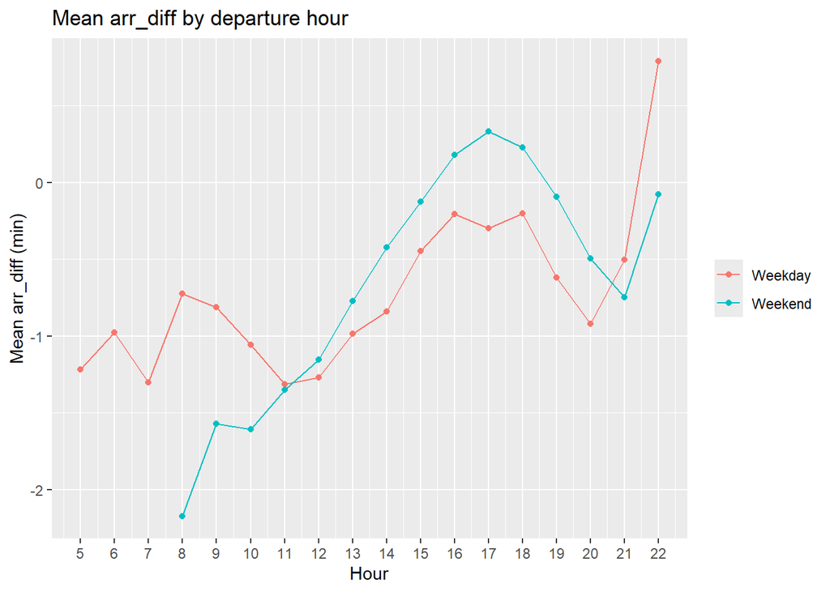

```r
ggplot(arr_by_hour, aes(x = dep_hour, y = mean, color = day_type)) +
  geom_line() +
  geom_point() +
  scale_x_continuous(breaks = 0:23) +
  labs(title = "Mean arr_diff by departure hour", x = "Hour", y = "Mean arr_diff (min)", color = NULL)
```

```r
corr_tbl <- dist_dat %>%
  filter(!is.na(arr_diff), !is.na(stop_volume)) %>%
  summarise(
    n = n(),
    cor = cor(arr_diff, stop_volume)
  )

corr_tbl
```

```
## # A tibble: 1 × 2
##        n   cor
##    <int> <dbl>
## 1 599681 0.160
```

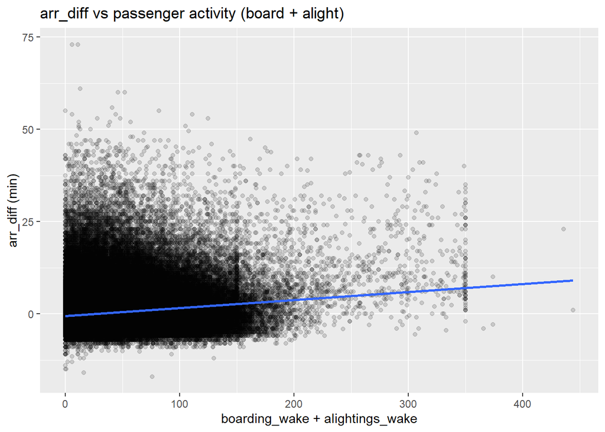

```r
ggplot(dist_dat %>% filter(!is.na(arr_diff), !is.na(stop_volume)),
       aes(x = stop_volume, y = arr_diff)) +
  geom_point(alpha = 0.15) +
  geom_smooth(method = "lm", se = FALSE) +
  labs(title = "arr_diff vs passenger activity (board + alight)",
       x = "boarding_wake + alightings_wake",
       y = "arr_diff (min)")
```

### arr_status (Late) patterns by route / month / weekday-weekend / hour

We summarize the share of stops classified as Late (arr_status == “Late”) across different dimensions. Missing statuses are excluded.

```r
late_dat <- dist_dat %>%
  filter(!is.na(arr_status)) %>%
  mutate(
    is_late = arr_status == "Late",
    month = floor_date(trip_date, "month"),
    day_type = if_else(is_weekday, "Weekday", "Weekend"),
    dep_hour = hour(actual_departure_dt)
  )
```

```r
late_by_route <- late_dat %>%
  group_by(route_no) %>%
  summarise(
    n = n(),
    pct_late = mean(is_late),
    p50_arr_diff = quantile(arr_diff, 0.50, na.rm = TRUE),
    p90_arr_diff = quantile(arr_diff, 0.90, na.rm = TRUE),
    .groups = "drop"
  ) %>%
  arrange(desc(pct_late))

late_by_route
```

```
## # A tibble: 8 × 5
##   route_no      n pct_late p50_arr_diff p90_arr_diff
##   <chr>     <int>    <dbl>        <dbl>        <dbl>
## 1 RW        31870   0.185             1         8
## 2 SV        95635   0.0900            0         5
## 3 RR          172   0.0872           -2         5
## 4 GI         1622   0.0660            0         4.1
## 5 SB       111098   0.0648           -1         4
## 6 ER       191089   0.0578           -1         3.58
## 7 AS       116669   0.0526           -1         3.05
## 8 SG        51553   0.0435           -1         3.15
```

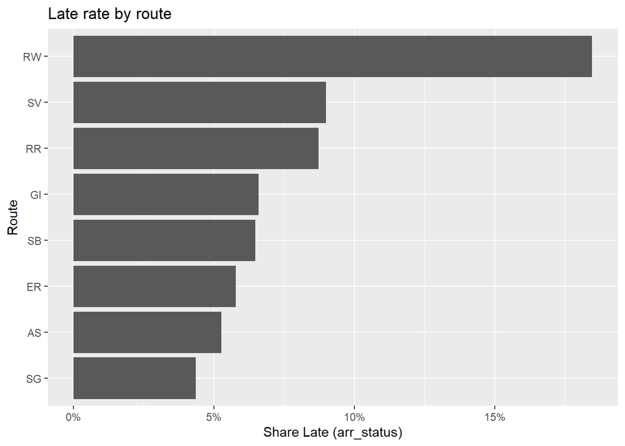

```r
ggplot(late_by_route, aes(x = reorder(route_no, pct_late), y = pct_late)) +
  geom_col() +
  coord_flip() +
  labs(title = "Late rate by route", x = "Route", y = "Share Late (arr_status)") +
  scale_y_continuous(labels = scales::percent_format())
```

```r
late_by_month <- late_dat %>%
  group_by(month, day_type) %>%
  summarise(
    n = n(),
    pct_late = mean(is_late),
    .groups = "drop"
  ) %>%
  arrange(month, day_type)

late_by_month
```

```
## # A tibble: 36 × 4
##    month      day_type     n pct_late
##    <date>     <chr>    <int>    <dbl>
##  1 2024-01-01 Weekday  24647   0.0394
##  2 2024-01-01 Weekend   4960   0.0756
##  3 2024-02-01 Weekday  23016   0.0374
##  4 2024-02-01 Weekend   5052   0.0954
##  5 2024-03-01 Weekday  23804   0.0436
##  6 2024-03-01 Weekend   7033   0.152
##  7 2024-04-01 Weekday  25597   0.0491
##  8 2024-04-01 Weekend   8033   0.0919
##  9 2024-05-01 Weekday  25981   0.0609
## 10 2024-05-01 Weekend   8548   0.0930
## # ℹ 26 more rows
```

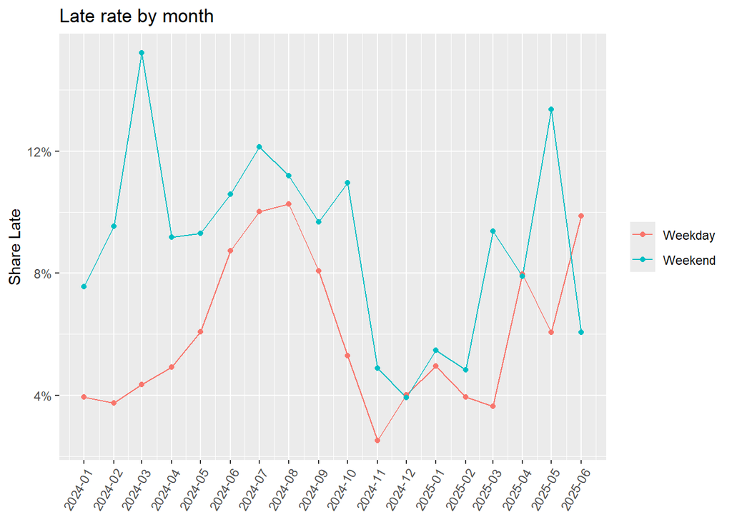

```r
ggplot(late_by_month, aes(x = month, y = pct_late, color = day_type)) +
  geom_line() +
  geom_point() +
  scale_x_date(date_breaks = "1 month", date_labels = "%Y-%m") +
  labs(title = "Late rate by month", x = NULL, y = "Share Late", color = NULL) +
  theme(axis.text.x = element_text(angle = 60, hjust = 1)) +
  scale_y_continuous(labels = scales::percent_format())
```

```r
late_by_daytype <- late_dat %>%
  group_by(day_type) %>%
  summarise(
    n = n(),
    pct_late = mean(is_late),
    .groups = "drop"
  )

late_by_daytype
```

```
## # A tibble: 2 × 3
##   day_type      n pct_late
##   <chr>     <int>    <dbl>
## 1 Weekday  451409   0.0607
## 2 Weekend  148299   0.0934
```

```r
late_by_hour <- late_dat %>%
  filter(!is.na(dep_hour), dep_hour != 23) %>%
  group_by(dep_hour, day_type) %>%
  summarise(
    n = n(),
    pct_late = mean(is_late),
    .groups = "drop"
  ) %>%
  arrange(dep_hour, day_type)

late_by_hour
```

```
## # A tibble: 33 × 4
##    dep_hour day_type     n pct_late
##       <int> <chr>    <int>    <dbl>
##  1        5 Weekday   2549   0.0118
##  2        6 Weekday  14258   0.0149
##  3        7 Weekday  25754   0.0116
##  4        8 Weekday  26789   0.0286
##  5        8 Weekend   1582   0.0107
##  6        9 Weekday  27503   0.0293
##  7        9 Weekend   6560   0.0194
##  8       10 Weekday  24011   0.0276
##  9       10 Weekend   6970   0.0191
## 10       11 Weekday  18792   0.0188
## # ℹ 23 more rows
```

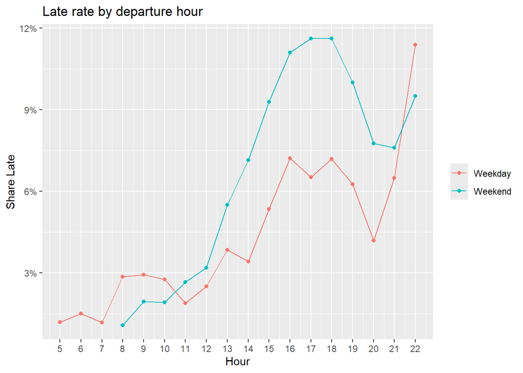

```r
ggplot(late_by_hour, aes(x = dep_hour, y = pct_late, color = day_type)) +
  geom_line() +
  geom_point() +
  scale_x_continuous(breaks = 0:22) +
  labs(title = "Late rate by departure hour", x = "Hour", y = "Share Late", color = NULL) +
  scale_y_continuous(labels = scales::percent_format())
```

### link Late to previous-stop passenger activity (prev board + alight)

We use passenger activity at the previous stop as a proxy for dwell-related delay propagation.

```r
late_dat_prev <- dist_dat %>%
  arrange(trip_date, route_no, route_direction, trip_no, Stop_Sequence) %>%
  mutate(
    is_late = !is.na(arr_status) & arr_status == "Late",
    month = floor_date(trip_date, "month"),
    day_type = if_else(is_weekday, "Weekday", "Weekend"),
    dep_hour = hour(actual_departure_dt),

    stop_volume = boarding_wake + alightings_wake,
    prev_stop_volume = lag(stop_volume),
    .by = c(trip_date, route_no, route_direction, trip_no)
  ) %>%
  # focus only on rows where we can evaluate lateness and have a previous stop
  filter(!is.na(arr_status), !is.na(prev_stop_volume))

late_vs_prev_volume <- late_dat_prev %>%
  mutate(
    prev_vol_bin = cut(prev_stop_volume,
                       breaks = c(-Inf, 0, 5, 10, 20, 50, 100, Inf),
                       include.lowest = TRUE)
  ) %>%
  group_by(prev_vol_bin) %>%
  summarise(
    n = n(),
    pct_late = mean(is_late),
    mean_arr_diff = mean(arr_diff, na.rm = TRUE),
    .groups = "drop"
  ) %>%
  arrange(prev_vol_bin)

late_vs_prev_volume
```

```
## # A tibble: 7 × 4
##   prev_vol_bin      n pct_late mean_arr_diff
##   <fct>         <int>    <dbl>         <dbl>
## 1 [-Inf,0]      14835   0.0517      -0.377
## 2 (0,5]         82837   0.0462      -0.419
## 3 (5,10]        81975   0.0466      -0.553
## 4 (10,20]      134727   0.0489      -0.486
## 5 (20,50]      192619   0.0691       0.00955
## 6 (50,100]      74914   0.116        1.08
## 7 (100, Inf]    17774   0.240        3.32
```

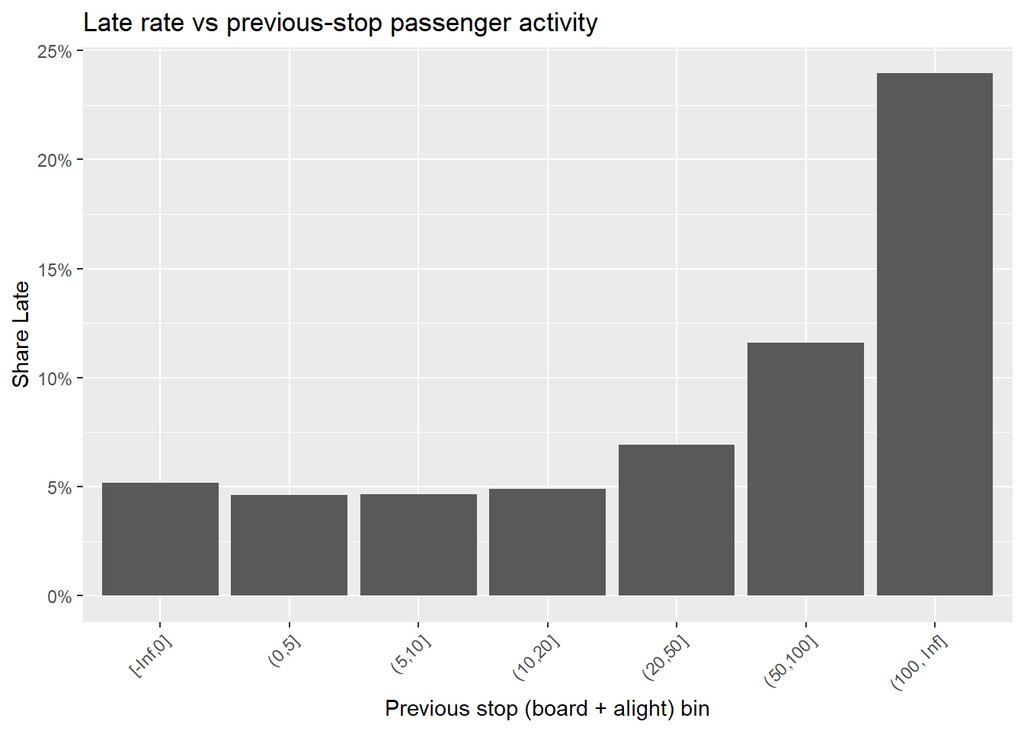

```r
ggplot(late_vs_prev_volume, aes(x = prev_vol_bin, y = pct_late)) +
  geom_col() +
  labs(title = "Late rate vs previous-stop passenger activity",
       x = "Previous stop (board + alight) bin",
       y = "Share Late") +
  scale_y_continuous(labels = scales::percent_format()) +
  theme(axis.text.x = element_text(angle = 45, hjust = 1))
```

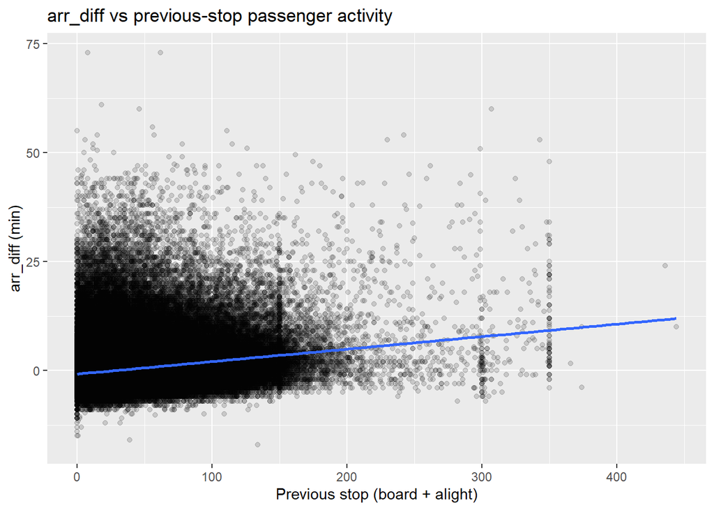

```r
ggplot(late_dat_prev %>% filter(!is.na(arr_diff)),
       aes(x = prev_stop_volume, y = arr_diff)) +
  geom_point(alpha = 0.15) +
  geom_smooth(method = "lm", se = FALSE) +
  labs(title = "arr_diff vs previous-stop passenger activity",
       x = "Previous stop (board + alight)",
       y = "arr_diff (min)")
```

### Direction comparison (NB vs SB): Weekday vs Weekend

We compare NB vs SB within each route panel. Metrics are computed at the trip level and then averaged by departure hour (0–22).

```r
# Trip-level table
trip_dir_tbl <- dat %>%
  filter(route_direction %in% c("NB", "SB")) %>%
  arrange(trip_date, route_no, route_direction, trip_no, Stop_Sequence) %>%
  group_by(trip_date, route_no, route_direction, trip_no) %>%
  summarise(
    is_weekday = first(is_weekday),
    trip_boardings = sum(boarding_wake, na.rm = TRUE),
    trip_dep_dt = first(actual_departure_dt),  # first stop departure
    trip_late_rate = mean(arr_status == "Late", na.rm = TRUE),
    .groups = "drop"
  ) %>%
  mutate(
    day_type = if_else(is_weekday, "Weekday", "Weekend"),
    dep_hour = hour(trip_dep_dt)
  ) %>%
  filter(!is.na(dep_hour), dep_hour >= 0, dep_hour <= 22)  # drop 23

dir_hour_summary <- trip_dir_tbl %>%
  group_by(route_no, route_direction, dep_hour, day_type) %>%
  summarise(
    n_trips = n(),
    avg_boardings_per_trip = mean(trip_boardings, na.rm = TRUE),
    avg_late_rate = mean(trip_late_rate, na.rm = TRUE),
    .groups = "drop"
  )
```

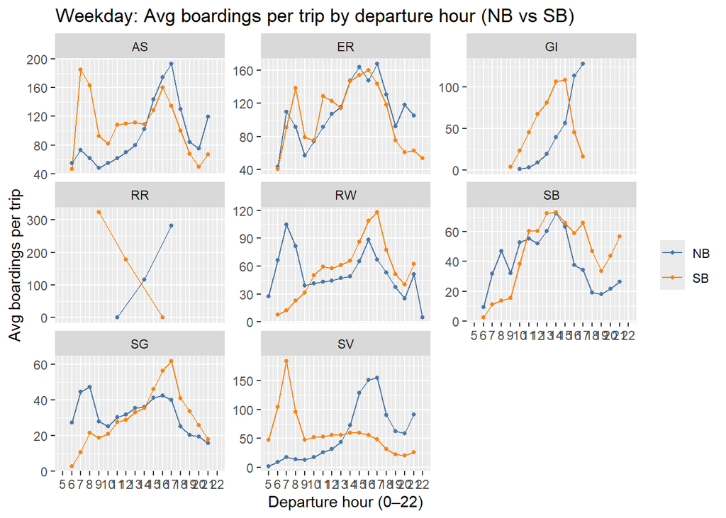

```r
ggplot(dir_hour_summary %>% filter(day_type == "Weekday"),
       aes(x = dep_hour, y = avg_boardings_per_trip, color = route_direction)) +
  geom_line() +
  geom_point(size = 1) +
  facet_wrap(~ route_no, scales = "free_y") +
  scale_x_continuous(breaks = 0:22) +
  labs(title = "Weekday: Avg boardings per trip by departure hour (NB vs SB)",
       x = "Departure hour (0–22)", y = "Avg boardings per trip", color = NULL) +
  scale_color_manual(values = c("NB" = "#4C78A8", "SB" = "#F58518"))
```

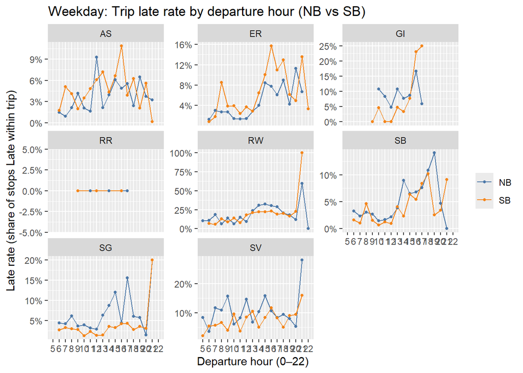

```r
ggplot(dir_hour_summary %>% filter(day_type == "Weekday"),
       aes(x = dep_hour, y = avg_late_rate, color = route_direction)) +
  geom_line() +
  geom_point(size = 1) +
  facet_wrap(~ route_no, scales = "free_y") +
  scale_x_continuous(breaks = 0:22) +
  labs(title = "Weekday: Trip late rate by departure hour (NB vs SB)",
       x = "Departure hour (0–22)", y = "Late rate (share of stops Late within trip)", color = NULL) +
  scale_color_manual(values = c("NB" = "#4C78A8", "SB" = "#F58518")) +
  scale_y_continuous(labels = scales::percent_format())
```

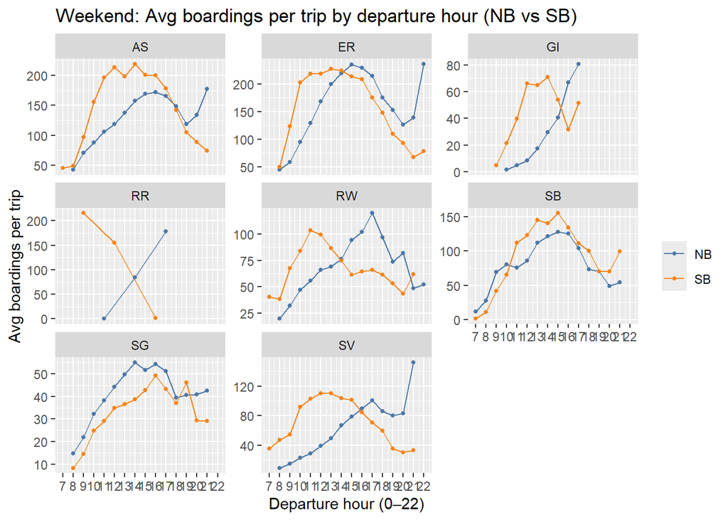

```r
ggplot(dir_hour_summary %>% filter(day_type == "Weekend"),
       aes(x = dep_hour, y = avg_boardings_per_trip, color = route_direction)) +
  geom_line() +
  geom_point(size = 1) +
  facet_wrap(~ route_no, scales = "free_y") +
  scale_x_continuous(breaks = 0:22) +
  labs(title = "Weekend: Avg boardings per trip by departure hour (NB vs SB)",
       x = "Departure hour (0–22)", y = "Avg boardings per trip", color = NULL) +
  scale_color_manual(values = c("NB" = "#4C78A8", "SB" = "#F58518"))
```

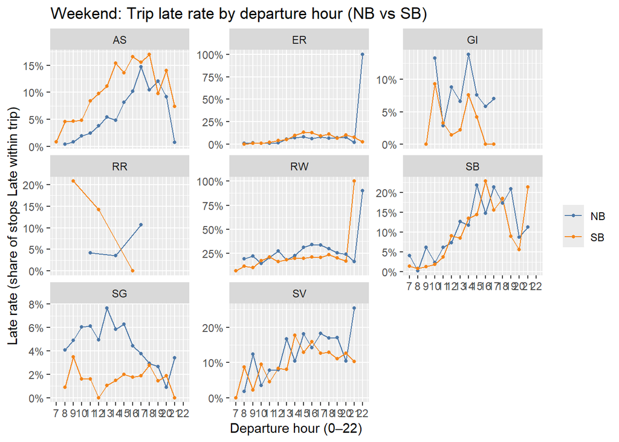

```r
ggplot(dir_hour_summary %>% filter(day_type == "Weekend"),
       aes(x = dep_hour, y = avg_late_rate, color = route_direction)) +
  geom_line() +
  geom_point(size = 1) +
  facet_wrap(~ route_no, scales = "free_y") +
  scale_x_continuous(breaks = 0:22) +
  labs(title = "Weekend: Trip late rate by departure hour (NB vs SB)",
       x = "Departure hour (0–22)", y = "Late rate (share of stops Late within trip)", color = NULL) +
  scale_color_manual(values = c("NB" = "#4C78A8", "SB" = "#F58518")) +
  scale_y_continuous(labels = scales::percent_format())
```